# Prediction

By Saba Akram

7/4/2021

In this project I am going to take the cereals dataset and apply the “Regression Model” on it to predict the “Ratings”(which will be my target variable) based on the nutrients given in the variables. Let’s import the dataset.

# Importing the Dataset

```r
cereals <- read.csv("D:/M.Sc BFA/Sem 3/Data Analytic and Machine learning/Data Mining and Predictive Analysis/Data sets/cereals.CSV", stringsAsFactors=TRUE)
head(cereals)
```

```
##                         Name Manuf Type Calories Protein Fat Sodium Fiber Carbo
## 1                 100%_Bran     N    C        70       4   1    130  10.0   5.0
## 2         100%_Natural_Bran     Q    C       120       3   5     15   2.0   8.0
## 3                  All-Bran     K    C        70       4   1    260   9.0   7.0
## 4 All-Bran_with_Extra_Fiber     K    C        50       4   0    140  14.0   8.0
## 5            Almond_Delight     R    C       110       2   2    200   1.0  14.0
## 6   Apple_Cinnamon_Cheerios     G    C       110       2   2    180   1.5  10.5
##   Sugars Potass Vitamins Shelf Weight Cups   Rating Cold Nabisco Quaker
## 1      6    280       25     3      1 0.33 68.40297    1       1      0
## 2      8    135        0     3      1 1.00 33.98368    1       0      1
## 3      5    320       25     3      1 0.33 59.42551    1       0      0
## 4      0    330       25     3      1 0.50 93.70491    1       0      0
## 5      8     NA       25     3      1 0.75 34.38484    1       0      0
## 6     10     70       25     1      1 0.75 29.50954    1       0      0
##   Kelloggs GeneralMills Ralston AHFP
## 1        0            0       0    0
## 2        0            0       0    0
## 3        1            0       0    0
## 4        1            0       0    0
## 5        0            0       1    0
## 6        0            1       0    0
```

```r
dim(cereals)
```

```
## [1] 77 23
```

- We see that there are 77 rows and 23 columns in the above dataset.

# Getting to know the columns

```r
colnames(cereals)
```

```
##  [1] "Name"         "Manuf"        "Type"         "Calories"     "Protein"
##  [6] "Fat"          "Sodium"       "Fiber"        "Carbo"        "Sugars"
## [11] "Potass"       "Vitamins"     "Shelf"        "Weight"       "Cups"
## [16] "Rating"       "Cold"         "Nabisco"      "Quaker"       "Kelloggs"
## [21] "GeneralMills" "Ralston"      "AHFP"
```

Apart from name, we see that Calories, Protein, Fat, Sodium, Fiber, Cargo, Sugars, Potass, Vitamins, Weights, cups are continuous variables; Shelf is the categorical variable. Also we see that Name, Manuf, Type, Cold, Nabisco, Quaker, Kellogs, GeneralMills, Ralston and AHFP are not required to build the model. Therefore, Let’s remove these columns.

```r
cereals<-cereals[,-c(1,2,3,17:23)]
colnames(cereals)
```

```
##  [1] "Calories" "Protein"  "Fat"      "Sodium"   "Fiber"    "Carbo"
##  [7] "Sugars"   "Potass"   "Vitamins" "Shelf"    "Weight"   "Cups"
## [13] "Rating"
```

# Checking Missing Values

```r
which(is.na(cereals$Fat))
```

```
## integer(0)
```

```r
which(is.na(cereals$Sodium))
```

```
## integer(0)
```

```r
which(is.na(cereals$Fiber))
```

```
## integer(0)
```

```r
which(is.na(cereals$Carbo))
```

```
## [1] 58
```

```r
which(is.na(cereals$Sugars))
```

```
## [1] 58
```

```r
which(is.na(cereals$Potass))
```

```
## [1]  5 21
```

```r
which(is.na(cereals$Vitamins))
```

```
## integer(0)
```

```r
which(is.na(cereals$Shelf))
```

```
## integer(0)
```

```r
which(is.na(cereals$Weight))
```

```
## integer(0)
```

```r
which(is.na(cereals$Cups))
```

```
## integer(0)
```

```r
which(is.na(cereals$Rating))
```

```
## integer(0)
```

After checking for missing values for each columns separately, we get that 58th record of the carbo and sugar is missing and 5th and 21st record of potass is missing. Let’s remove them.

```r
cereals<-cereals[-c(5,21,58),]
```

# Creating Indicator Variables

```r
cereals$Shelf1<-ifelse(cereals$Shelf==1,1,0)
cereals$shelf2<-ifelse(cereals$Shelf==2,1,0)
```

Now we have all the required variables ready. I am going to use the forward selection method for predicting the ratings of the cereals dataset.

# Forward Selection Procedure

- Step 1. It starts with no variables in the model.
- Step 2. Most highly correlated predictor with the target variable is entered into the model. If the resulting model is significant, then move forward otherwise report that no variables are important predictors.
- Step 3. For each remaining variables compute sequential F-Statistic for that variable, given the variables already in the model. For example in the first pass through the algorithm, these sequential F-Statistic would be F(x2|x1),F(x3|x1), F(x4|x1) and so on. On the second pass through the algorithm, these might be F(x3|x1,x2), F(x4|x1,x2),F(x5|x1,x2) and so on and so on. The variable with the largest sequential F-Statistic is selected.
- Step 4. For the variable selected in earlier step, test for the significance of the Sequential F-Statistic. If significant, then again perform step 3, otherwise stop and report the current model.

# Finding the predictor most highly correlated with the Response variable “Rating”.

```r
cereals_predictors<-cereals[,-13]
colnames(cereals_predictors)
```

```
##  [1] "Calories" "Protein"  "Fat"      "Sodium"   "Fiber"    "Carbo"
##  [7] "Sugars"   "Potass"   "Vitamins" "Shelf"    "Weight"   "Cups"
## [13] "Shelf1"   "shelf2"
```

```r
cor(cereals$Rating,cereals_predictors)
```

```
##        Calories   Protein        Fat     Sodium     Fiber      Carbo     Sugars
## [1,] -0.6937847 0.4671622 -0.4050502 -0.3830124 0.6034109 0.05594129 -0.7559551
##         Potass   Vitamins      Shelf    Weight       Cups    Shelf1     shelf2
## [1,] 0.4157824 -0.2144809 0.05103975 -0.300461 -0.2225044 0.1487322 -0.3875847
```

# Building Linear Model

```r
reg1<-lm(cereals$Rating~cereals$Sugars)
summary(reg1)
```

```
##
## Call:
## lm(formula = cereals$Rating ~ cereals$Sugars)
##
## Residuals:
##     Min      1Q  Median      3Q     Max
## -17.944  -5.596  -1.380   4.773  34.034
##
## Coefficients:
##                Estimate Std. Error t value Pr(>|t|)
## (Intercept)     59.6709     2.0672  28.866  < 2e-16 ***
## cereals$Sugars  -2.4337     0.2484  -9.799 6.92e-15 ***
## ---
## Signif. codes:  0 '***' 0.001 '**' 0.01 '*' 0.05 '.' 0.1 ' ' 1
##
## Residual standard error: 9.25 on 72 degrees of freedom
## Multiple R-squared:  0.5715, Adjusted R-squared:  0.5655
## F-statistic: 96.02 on 1 and 72 DF,  p-value: 6.924e-15
```

```r
anova(reg1)
```

```
## Analysis of Variance Table
##
## Response: cereals$Rating
##                Df Sum Sq Mean Sq F value    Pr(>F)
## cereals$Sugars  1   8216  8216.0  96.016 6.924e-15 ***
## Residuals      72   6161    85.6
## ---
## Signif. codes:  0 '***' 0.001 '**' 0.01 '*' 0.05 '.' 0.1 ' ' 1
```

- Though R-Square is little less i.e 0.5715, but as we can see we have a very high value of F-statistic of 96.02 and a very low p-value with standard error of 9.25 indicating that sugar is important in predicting the Rating of the cereal.

# Plotting the Regression line.

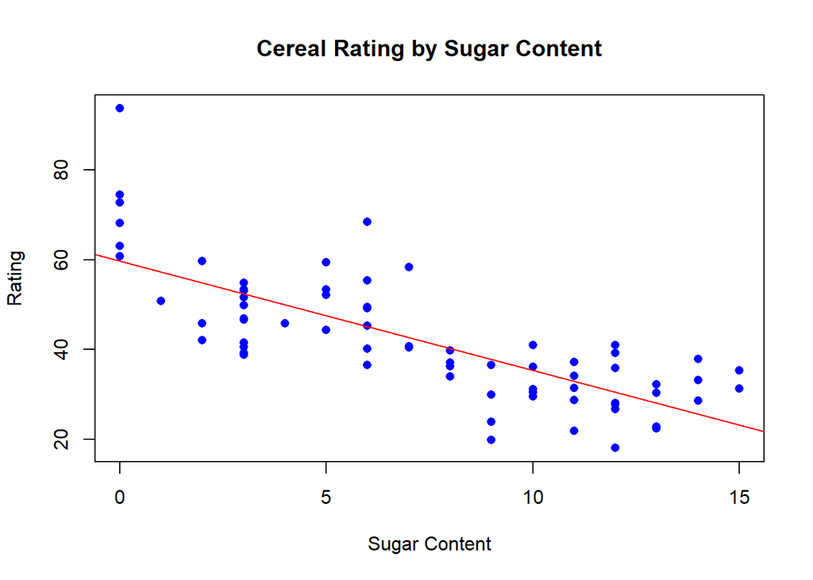

```r
plot(cereals$Sugars,cereals$Rating,main = "Cereal Rating by Sugar Content",xlab = "Sugar Content",ylab = "Rating",pch=16,col="blue")
abline(reg1,col="red")
```

# First Sequential F-Statistic all the remaining variables.

```r
F1<-lm(cereals$Rating~cereals$Sugars+cereals$Calories)
summary(F1)
```

```
##
## Call:
## lm(formula = cereals$Rating ~ cereals$Sugars + cereals$Calories)
##
## Residuals:
##     Min      1Q  Median      3Q     Max
## -15.719  -6.334  -1.088   4.695  23.390
##
## Coefficients:
##                  Estimate Std. Error t value Pr(>|t|)
## (Intercept)      84.09930    5.47241  15.368  < 2e-16 ***
## cereals$Sugars   -1.71949    0.26522  -6.483 1.03e-08 ***
## cereals$Calories -0.27568    0.05826  -4.732 1.10e-05 ***
## ---
## Signif. codes:  0 '***' 0.001 '**' 0.01 '*' 0.05 '.' 0.1 ' ' 1
##
## Residual standard error: 8.122 on 71 degrees of freedom
## Multiple R-squared:  0.6742, Adjusted R-squared:  0.665
## F-statistic: 73.46 on 2 and 71 DF,  p-value: < 2.2e-16
```

```r
F2<-lm(cereals$Rating~cereals$Sugars+cereals$Protein)
summary(F2)
```

```
##
## Call:
## lm(formula = cereals$Rating ~ cereals$Sugars + cereals$Protein)
##
## Residuals:
##     Min      1Q  Median      3Q     Max
## -17.347  -6.054  -1.754   5.524  30.531
##
## Coefficients:
##                 Estimate Std. Error t value Pr(>|t|)
## (Intercept)      48.9319     3.4925  14.010  < 2e-16 ***
## cereals$Sugars   -2.1819     0.2393  -9.117 1.43e-13 ***
## cereals$Protein   3.5604     0.9698   3.671 0.000464 ***
## ---
## Signif. codes:  0 '***' 0.001 '**' 0.01 '*' 0.05 '.' 0.1 ' ' 1
##
## Residual standard error: 8.54 on 71 degrees of freedom
## Multiple R-squared:  0.6398, Adjusted R-squared:  0.6297
## F-statistic: 63.07 on 2 and 71 DF,  p-value: < 2.2e-16
```

```r
F3<-lm(cereals$Rating~cereals$Sugars+cereals$Fat)
summary(F3)
```

```
##
## Call:
## lm(formula = cereals$Rating ~ cereals$Sugars + cereals$Fat)
##
## Residuals:
##     Min      1Q  Median      3Q     Max
## -14.693  -5.485   0.148   4.894  32.525
##
## Coefficients:
##                Estimate Std. Error t value Pr(>|t|)
## (Intercept)     61.1803     2.0661  29.611  < 2e-16 ***
## cereals$Sugars  -2.2443     0.2491  -9.010 2.25e-13 ***
## cereals$Fat     -2.8556     1.0785  -2.648  0.00998 **
## ---
## Signif. codes:  0 '***' 0.001 '**' 0.01 '*' 0.05 '.' 0.1 ' ' 1
##
## Residual standard error: 8.887 on 71 degrees of freedom
## Multiple R-squared:   0.61,  Adjusted R-squared:  0.599
## F-statistic: 55.52 on 2 and 71 DF,  p-value: 3.045e-15
```

```r
F4<-lm(cereals$Rating~cereals$Sugars+cereals$Sodium)
summary(F4)
```

```
##
## Call:
## lm(formula = cereals$Rating ~ cereals$Sugars + cereals$Sodium)
##
## Residuals:
##     Min      1Q  Median      3Q     Max
## -15.153  -4.437  -0.772   3.012  32.987
##
## Coefficients:
##                Estimate Std. Error t value Pr(>|t|)
## (Intercept)    69.15568    2.46835  28.017  < 2e-16 ***
## cereals$Sugars -2.39131    0.21023 -11.375  < 2e-16 ***
## cereals$Sodium -0.06027    0.01107  -5.444 7.06e-07 ***
## ---
## Signif. codes:  0 '***' 0.001 '**' 0.01 '*' 0.05 '.' 0.1 ' ' 1
##
## Residual standard error: 7.824 on 71 degrees of freedom
## Multiple R-squared:  0.6977, Adjusted R-squared:  0.6891
## F-statistic: 81.92 on 2 and 71 DF,  p-value: < 2.2e-16
```

```r
F5<-lm(cereals$Rating~cereals$Sugars+cereals$Fiber)
summary(F5)
```

```
##
## Call:
## lm(formula = cereals$Rating ~ cereals$Sugars + cereals$Fiber)
##
## Residuals:
##     Min      1Q  Median      3Q     Max
## -12.096  -4.302  -1.017   2.610  16.476
##
## Coefficients:
##                Estimate Std. Error t value Pr(>|t|)
## (Intercept)     51.6328     1.5930  32.412  < 2e-16 ***
## cereals$Sugars  -2.1904     0.1656 -13.229  < 2e-16 ***
## cereals$Fiber    2.8996     0.2978   9.735 1.04e-14 ***
## ---
## Signif. codes:  0 '***' 0.001 '**' 0.01 '*' 0.05 '.' 0.1 ' ' 1
##
## Residual standard error: 6.096 on 71 degrees of freedom
## Multiple R-squared:  0.8165, Adjusted R-squared:  0.8113
## F-statistic: 157.9 on 2 and 71 DF,  p-value: < 2.2e-16
```

```r
F6<-lm(cereals$Rating~cereals$Sugars+cereals$Carbo)
summary(F6)
```

```
##
## Call:
## lm(formula = cereals$Rating ~ cereals$Sugars + cereals$Carbo)
##
## Residuals:
##     Min      1Q  Median      3Q     Max
## -19.195  -6.007  -1.082   6.001  21.601
##
## Coefficients:
##                Estimate Std. Error t value Pr(>|t|)
## (Intercept)     82.4673     5.1505   16.01  < 2e-16 ***
## cereals$Sugars  -2.9565     0.2445  -12.09  < 2e-16 ***
## cereals$Carbo   -1.2954     0.2739   -4.73 1.11e-05 ***
## ---
## Signif. codes:  0 '***' 0.001 '**' 0.01 '*' 0.05 '.' 0.1 ' ' 1
##
## Residual standard error: 8.123 on 71 degrees of freedom
## Multiple R-squared:  0.6741, Adjusted R-squared:  0.665
## F-statistic: 73.44 on 2 and 71 DF,  p-value: < 2.2e-16
```

```r
F7<-lm(cereals$Rating~cereals$Sugars+cereals$Potass)
summary(F7)
```

```
##
## Call:
## lm(formula = cereals$Rating ~ cereals$Sugars + cereals$Potass)
##
## Residuals:
##     Min      1Q  Median      3Q     Max
## -13.524  -4.812  -1.714   4.168  16.932
##
## Coefficients:
##                Estimate Std. Error t value Pr(>|t|)
## (Intercept)    51.55359    1.98415  25.983  < 2e-16 ***
## cereals$Sugars -2.43562    0.19285 -12.630  < 2e-16 ***
## cereals$Potass  0.08254    0.01186   6.959  1.4e-09 ***
## ---
## Signif. codes:  0 '***' 0.001 '**' 0.01 '*' 0.05 '.' 0.1 ' ' 1
##
## Residual standard error: 7.183 on 71 degrees of freedom
## Multiple R-squared:  0.7452, Adjusted R-squared:  0.7381
## F-statistic: 103.8 on 2 and 71 DF,  p-value: < 2.2e-16
```

```r
F8<-lm(cereals$Rating~cereals$Sugars+cereals$Vitamins)
summary(F8)
```

```
##
## Call:
## lm(formula = cereals$Rating ~ cereals$Sugars + cereals$Vitamins)
##
## Residuals:
##     Min      1Q  Median      3Q     Max
## -18.424  -5.383  -1.191   4.980  33.893
##
## Coefficients:
##                  Estimate Std. Error t value Pr(>|t|)
## (Intercept)      62.33306    2.37727  26.220  < 2e-16 ***
## cereals$Sugars   -2.39610    0.24320  -9.852 6.38e-15 ***
## cereals$Vitamins -0.10083    0.04755  -2.120   0.0375 *
## ---
## Signif. codes:  0 '***' 0.001 '**' 0.01 '*' 0.05 '.' 0.1 ' ' 1
##
## Residual standard error: 9.034 on 71 degrees of freedom
## Multiple R-squared:  0.597,  Adjusted R-squared:  0.5856
## F-statistic: 52.59 on 2 and 71 DF,  p-value: 9.743e-15
```

```r
F9<-lm(cereals$Rating~cereals$Sugars+cereals$Weight)
summary(F9)
```

```
##
## Call:
## lm(formula = cereals$Rating ~ cereals$Sugars + cereals$Weight)
##
## Residuals:
##     Min      1Q  Median      3Q     Max
## -17.603  -5.603  -1.403   4.845  33.567
##
## Coefficients:
##                Estimate Std. Error t value Pr(>|t|)
## (Intercept)     54.6012     7.5947   7.189 5.27e-10 ***
## cereals$Sugars  -2.5235     0.2808  -8.986 2.49e-13 ***
## cereals$Weight   5.5371     7.9793   0.694     0.49
## ---
## Signif. codes:  0 '***' 0.001 '**' 0.01 '*' 0.05 '.' 0.1 ' ' 1
##
## Residual standard error: 9.284 on 71 degrees of freedom
## Multiple R-squared:  0.5744, Adjusted R-squared:  0.5624
## F-statistic:  47.9 on 2 and 71 DF,  p-value: 6.779e-14
```

```r
F10<-lm(cereals$Rating~cereals$Sugars+cereals$Cups)
summary(F10)
```

```
##
## Call:
## lm(formula = cereals$Rating ~ cereals$Sugars + cereals$Cups)
##
## Residuals:
##     Min      1Q  Median      3Q     Max
## -18.950  -5.771  -1.490   5.708  29.115
##
## Coefficients:
##                Estimate Std. Error t value Pr(>|t|)
## (Intercept)     71.9508     4.0610  17.718  < 2e-16 ***
## cereals$Sugars  -2.4595     0.2317 -10.614 2.66e-16 ***
## cereals$Cups   -14.7225     4.2853  -3.436 0.000992 ***
## ---
## Signif. codes:  0 '***' 0.001 '**' 0.01 '*' 0.05 '.' 0.1 ' ' 1
##
## Residual standard error: 8.626 on 71 degrees of freedom
## Multiple R-squared:  0.6326, Adjusted R-squared:  0.6222
## F-statistic: 61.11 on 2 and 71 DF,  p-value: 3.668e-16
```

```r
F11<-lm(cereals$Rating~cereals$Sugars+cereals$Shelf1)
summary(F11)
```

```
##
## Call:
## lm(formula = cereals$Rating ~ cereals$Sugars + cereals$Shelf1)
##
## Residuals:
##     Min      1Q  Median      3Q     Max
## -18.345  -5.448  -1.150   4.823  33.150
##
## Coefficients:
##                Estimate Std. Error t value Pr(>|t|)
## (Intercept)     60.5551     2.3751  25.496  < 2e-16 ***
## cereals$Sugars  -2.4874     0.2588  -9.610 1.77e-14 ***
## cereals$Shelf1  -1.9573     2.5654  -0.763    0.448
## ---
## Signif. codes:  0 '***' 0.001 '**' 0.01 '*' 0.05 '.' 0.1 ' ' 1
##
## Residual standard error: 9.277 on 71 degrees of freedom
## Multiple R-squared:  0.575,  Adjusted R-squared:  0.563
## F-statistic: 48.02 on 2 and 71 DF,  p-value: 6.449e-14
```

```r
F12<-lm(cereals$Rating~cereals$Sugars+cereals$shelf2)
summary(F12)
```

```
##
## Call:
## lm(formula = cereals$Rating ~ cereals$Sugars + cereals$shelf2)
##
## Residuals:
##     Min      1Q  Median      3Q     Max
## -16.222  -5.879  -1.327   4.844  34.131
##
## Coefficients:
##                Estimate Std. Error t value Pr(>|t|)
## (Intercept)     59.5744     2.0696  28.786  < 2e-16 ***
## cereals$Sugars  -2.3191     0.2738  -8.471 2.24e-12 ***
## cereals$shelf2  -2.6564     2.6690  -0.995    0.323
## ---
## Signif. codes:  0 '***' 0.001 '**' 0.01 '*' 0.05 '.' 0.1 ' ' 1
##
## Residual standard error: 9.251 on 71 degrees of freedom
## Multiple R-squared:  0.5774, Adjusted R-squared:  0.5655
## F-statistic:  48.5 on 2 and 71 DF,  p-value: 5.27e-14
```

After checking the summary of each of the remaining variables and observing the Sequential F-Statistic, we get the variable fiber has the highest Sequential F-Statistic of 157.9 with coefficient 2.8996 and a p-value of 0. Also the Standard error decreased to 6.096. Hence this variable is significant.

```r
reg2<-lm(cereals$Rating~cereals$Sugars+cereals$Fiber)
summary(reg2)
```

```
##
## Call:
## lm(formula = cereals$Rating ~ cereals$Sugars + cereals$Fiber)
##
## Residuals:
##     Min      1Q  Median      3Q     Max
## -12.096  -4.302  -1.017   2.610  16.476
##
## Coefficients:
##                Estimate Std. Error t value Pr(>|t|)
## (Intercept)     51.6328     1.5930  32.412  < 2e-16 ***
## cereals$Sugars  -2.1904     0.1656 -13.229  < 2e-16 ***
## cereals$Fiber    2.8996     0.2978   9.735 1.04e-14 ***
## ---
## Signif. codes:  0 '***' 0.001 '**' 0.01 '*' 0.05 '.' 0.1 ' ' 1
##
## Residual standard error: 6.096 on 71 degrees of freedom
## Multiple R-squared:  0.8165, Adjusted R-squared:  0.8113
## F-statistic: 157.9 on 2 and 71 DF,  p-value: < 2.2e-16
```

```r
anova(reg2)
```

```
## Analysis of Variance Table
##
## Response: cereals$Rating
##                Df Sum Sq Mean Sq F value    Pr(>F)
## cereals$Sugars  1 8216.0  8216.0 221.071 < 2.2e-16 ***
## cereals$Fiber   1 3522.3  3522.3  94.777 1.043e-14 ***
## Residuals      71 2638.7    37.2
## ---
## Signif. codes:  0 '***' 0.001 '**' 0.01 '*' 0.05 '.' 0.1 ' ' 1
```

The R Square jumped to 0.8165 and also as we can see we have a very high value of F-statistic of 157.9 and a p-value of 0 with decreased standard error of 6.096 indicating that sugar and fiber are important in predicting the Rating of the cereals.

# Plotting the scatter plot

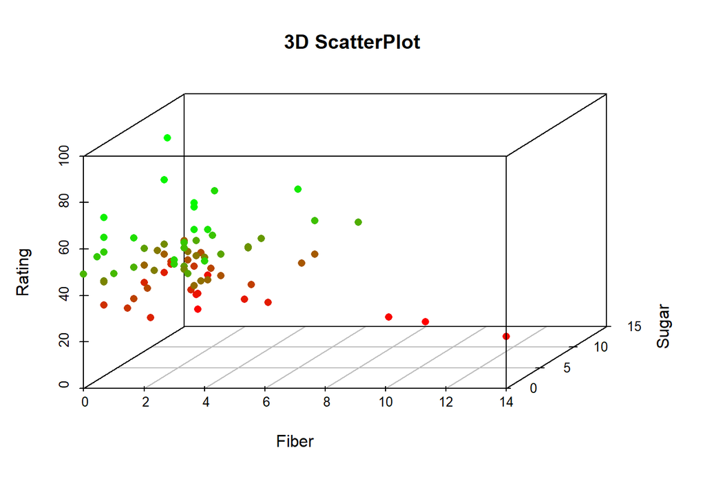

```r
library(scatterplot3d)
rg<-colorRampPalette(c("red","green"))(74)
sp<-scatterplot3d(z=sort(cereals$Rating),y=cereals$Sugars,x=cereals$Fiber,color=rg,pch=16,xlab="Fiber",ylab="Sugar",zlab="Rating",main="3D ScatterPlot")
```

# Second Sequential F-Statistic all the remaining variables.

```r
F1=lm(cereals$Rating~cereals$Sugars+cereals$Fiber+cereals$Calories)
summary(F1)
```

```
##
## Call:
## lm(formula = cereals$Rating ~ cereals$Sugars + cereals$Fiber +
##     cereals$Calories)
##
## Residuals:
##      Min       1Q   Median       3Q      Max
## -11.2893  -3.1893  -0.9493   3.0109  12.7883
##
## Coefficients:
##                  Estimate Std. Error t value Pr(>|t|)
## (Intercept)      68.25709    4.02686  16.950  < 2e-16 ***
## cereals$Sugars   -1.75579    0.17738  -9.898 6.10e-15 ***
## cereals$Fiber     2.58766    0.27460   9.423 4.45e-14 ***
## cereals$Calories -0.17785    0.04032  -4.411 3.64e-05 ***
## ---
## Signif. codes:  0 '***' 0.001 '**' 0.01 '*' 0.05 '.' 0.1 ' ' 1
##
## Residual standard error: 5.431 on 70 degrees of freedom
## Multiple R-squared:  0.8564, Adjusted R-squared:  0.8502
## F-statistic: 139.1 on 3 and 70 DF,  p-value: < 2.2e-16
```

```r
F2=lm(cereals$Rating~cereals$Sugars+cereals$Fiber+cereals$Protein)
summary(F2)
```

```
##
## Call:
## lm(formula = cereals$Rating ~ cereals$Sugars + cereals$Fiber +
##     cereals$Protein)
##
## Residuals:
##      Min       1Q   Median       3Q      Max
## -11.8306  -4.3286  -0.8466   2.6378  16.3726
##
## Coefficients:
##                 Estimate Std. Error t value Pr(>|t|)
## (Intercept)      50.9553     2.5208  20.214  < 2e-16 ***
## cereals$Sugars   -2.1756     0.1719 -12.655  < 2e-16 ***
## cereals$Fiber     2.8398     0.3454   8.222 7.12e-12 ***
## cereals$Protein   0.2796     0.8028   0.348    0.729
## ---
## Signif. codes:  0 '***' 0.001 '**' 0.01 '*' 0.05 '.' 0.1 ' ' 1
##
## Residual standard error: 6.134 on 70 degrees of freedom
## Multiple R-squared:  0.8168, Adjusted R-squared:  0.8089
## F-statistic:   104 on 3 and 70 DF,  p-value: < 2.2e-16
```

```r
F3=lm(cereals$Rating~cereals$Sugars+cereals$Fiber+cereals$Fat)
summary(F3)
```

```
##
## Call:
## lm(formula = cereals$Rating ~ cereals$Sugars + cereals$Fiber +
##     cereals$Fat)
##
## Residuals:
##     Min      1Q  Median      3Q     Max
## -8.7390 -3.5705 -0.9461  3.1922 11.5639
##
## Coefficients:
##                Estimate Std. Error t value Pr(>|t|)
## (Intercept)     53.1558     1.3924  38.176  < 2e-16 ***
## cereals$Sugars  -1.9645     0.1480 -13.275  < 2e-16 ***
## cereals$Fiber    2.9802     0.2550  11.686  < 2e-16 ***
## cereals$Fat     -3.3042     0.6334  -5.216 1.77e-06 ***
## ---
## Signif. codes:  0 '***' 0.001 '**' 0.01 '*' 0.05 '.' 0.1 ' ' 1
##
## Residual standard error: 5.21 on 70 degrees of freedom
## Multiple R-squared:  0.8678, Adjusted R-squared:  0.8622
## F-statistic: 153.2 on 3 and 70 DF,  p-value: < 2.2e-16
```

```r
F4=lm(cereals$Rating~cereals$Sugars+cereals$Fiber+cereals$Sodium)
summary(F4)
```

```
##
## Call:
## lm(formula = cereals$Rating ~ cereals$Sugars + cereals$Fiber +
##     cereals$Sodium)
##
## Residuals:
##      Min       1Q   Median       3Q      Max
## -14.0735  -1.8040   0.1987   2.1807   9.5288
##
## Coefficients:
##                 Estimate Std. Error t value Pr(>|t|)
## (Intercept)    60.630687   1.407916  43.064  < 2e-16 ***
## cereals$Sugars -2.162213   0.109451 -19.755  < 2e-16 ***
## cereals$Fiber   2.774417   0.197236  14.066  < 2e-16 ***
## cereals$Sodium -0.054974   0.005713  -9.623 1.92e-14 ***
## ---
## Signif. codes:  0 '***' 0.001 '**' 0.01 '*' 0.05 '.' 0.1 ' ' 1
##
## Residual standard error: 4.028 on 70 degrees of freedom
## Multiple R-squared:  0.921,  Adjusted R-squared:  0.9176
## F-statistic:   272 on 3 and 70 DF,  p-value: < 2.2e-16
```

```r
F5=lm(cereals$Rating~cereals$Sugars+cereals$Fiber+cereals$Carbo)
summary(F5)
```

```
##
## Call:
## lm(formula = cereals$Rating ~ cereals$Sugars + cereals$Fiber +
##     cereals$Carbo)
##
## Residuals:
##      Min       1Q   Median       3Q      Max
## -13.0196  -3.7365  -0.6307   2.4750  15.8503
##
## Coefficients:
##                Estimate Std. Error t value Pr(>|t|)
## (Intercept)     59.0418     4.8937  12.065  < 2e-16 ***
## cereals$Sugars  -2.3659     0.1972 -11.999  < 2e-16 ***
## cereals$Fiber    2.6222     0.3419   7.670  7.4e-11 ***
## cereals$Carbo   -0.3773     0.2359  -1.599    0.114
## ---
## Signif. codes:  0 '***' 0.001 '**' 0.01 '*' 0.05 '.' 0.1 ' ' 1
##
## Residual standard error: 6.03 on 70 degrees of freedom
## Multiple R-squared:  0.8229, Adjusted R-squared:  0.8153
## F-statistic: 108.4 on 3 and 70 DF,  p-value: < 2.2e-16
```

```r
F6=lm(cereals$Rating~cereals$Sugars+cereals$Fiber+cereals$Potass)
summary(F6)
```

```
##
## Call:
## lm(formula = cereals$Rating ~ cereals$Sugars + cereals$Fiber +
##     cereals$Potass)
##
## Residuals:
##      Min       1Q   Median       3Q      Max
## -12.0179  -3.8631  -0.9719   2.0831  15.5612
##
## Coefficients:
##                Estimate Std. Error t value Pr(>|t|)
## (Intercept)    52.82609    1.66151  31.794  < 2e-16 ***
## cereals$Sugars -2.06883    0.17229 -12.008  < 2e-16 ***
## cereals$Fiber   4.33372    0.75350   5.751 2.14e-07 ***
## cereals$Potass -0.05256    0.02547  -2.064   0.0428 *
## ---
## Signif. codes:  0 '***' 0.001 '**' 0.01 '*' 0.05 '.' 0.1 ' ' 1
##
## Residual standard error: 5.961 on 70 degrees of freedom
## Multiple R-squared:  0.827,  Adjusted R-squared:  0.8196
## F-statistic: 111.5 on 3 and 70 DF,  p-value: < 2.2e-16
```

```r
F7=lm(cereals$Rating~cereals$Sugars+cereals$Fiber+cereals$Vitamins)
summary(F7)
```

```
##
## Call:
## lm(formula = cereals$Rating ~ cereals$Sugars + cereals$Fiber +
##     cereals$Vitamins)
##
## Residuals:
##      Min       1Q   Median       3Q      Max
## -12.5827  -4.0604  -0.8194   2.4049  15.7944
##
## Coefficients:
##                  Estimate Std. Error t value Pr(>|t|)
## (Intercept)      54.13168    1.71907  31.489  < 2e-16 ***
## cereals$Sugars   -2.15804    0.15715 -13.732  < 2e-16 ***
## cereals$Fiber     2.87555    0.28214  10.192  1.8e-15 ***
## cereals$Vitamins -0.09213    0.03040  -3.031  0.00342 **
## ---
## Signif. codes:  0 '***' 0.001 '**' 0.01 '*' 0.05 '.' 0.1 ' ' 1
##
## Residual standard error: 5.773 on 70 degrees of freedom
## Multiple R-squared:  0.8378, Adjusted R-squared:  0.8308
## F-statistic: 120.5 on 3 and 70 DF,  p-value: < 2.2e-16
```

```r
F8=lm(cereals$Rating~cereals$Sugars+cereals$Fiber+cereals$Weight)
summary(F8)
```

```
##
## Call:
## lm(formula = cereals$Rating ~ cereals$Sugars + cereals$Fiber +
##     cereals$Weight)
##
## Residuals:
##      Min       1Q   Median       3Q      Max
## -12.3934  -3.6745  -0.7463   2.8021  14.5936
##
## Coefficients:
##                Estimate Std. Error t value Pr(>|t|)
## (Intercept)     64.2841     4.8617   13.22  < 2e-16 ***
## cereals$Sugars  -1.9264     0.1855  -10.39 8.06e-16 ***
## cereals$Fiber    3.2009     0.3055   10.48 5.57e-16 ***
## cereals$Weight -14.7300     5.3749   -2.74  0.00778 **
## ---
## Signif. codes:  0 '***' 0.001 '**' 0.01 '*' 0.05 '.' 0.1 ' ' 1
##
## Residual standard error: 5.835 on 70 degrees of freedom
## Multiple R-squared:  0.8342, Adjusted R-squared:  0.8271
## F-statistic: 117.4 on 3 and 70 DF,  p-value: < 2.2e-16
```

```r
F9=lm(cereals$Rating~cereals$Sugars+cereals$Fiber+cereals$Cups)
summary(F9)
```

```
##
## Call:
## lm(formula = cereals$Rating ~ cereals$Sugars + cereals$Fiber +
##     cereals$Cups)
##
## Residuals:
##     Min      1Q  Median      3Q     Max
## -11.916  -4.372  -1.032   2.531  16.482
##
## Coefficients:
##                Estimate Std. Error t value Pr(>|t|)
## (Intercept)     50.6167     3.8494  13.149  < 2e-16 ***
## cereals$Sugars  -2.1841     0.1681 -12.994  < 2e-16 ***
## cereals$Fiber    2.9533     0.3522   8.385 3.57e-12 ***
## cereals$Cups     1.0398     3.5813   0.290    0.772
## ---
## Signif. codes:  0 '***' 0.001 '**' 0.01 '*' 0.05 '.' 0.1 ' ' 1
##
## Residual standard error: 6.136 on 70 degrees of freedom
## Multiple R-squared:  0.8167, Adjusted R-squared:  0.8088
## F-statistic:   104 on 3 and 70 DF,  p-value: < 2.2e-16
```

```r
F10=lm(cereals$Rating~cereals$Sugars+cereals$Fiber+cereals$Shelf1)
summary(F10)
```

```
##
## Call:
## lm(formula = cereals$Rating ~ cereals$Sugars + cereals$Fiber +
##     cereals$Shelf1)
##
## Residuals:
##     Min      1Q  Median      3Q     Max
## -11.804  -4.830  -1.219   2.803  15.493
##
## Coefficients:
##                Estimate Std. Error t value Pr(>|t|)
## (Intercept)     51.0488     1.8516  27.570  < 2e-16 ***
## cereals$Sugars  -2.1579     0.1742 -12.387  < 2e-16 ***
## cereals$Fiber    2.9344     0.3042   9.645 1.76e-14 ***
## cereals$Shelf1   1.0789     1.7220   0.627    0.533
## ---
## Signif. codes:  0 '***' 0.001 '**' 0.01 '*' 0.05 '.' 0.1 ' ' 1
##
## Residual standard error: 6.123 on 70 degrees of freedom
## Multiple R-squared:  0.8175, Adjusted R-squared:  0.8097
## F-statistic: 104.5 on 3 and 70 DF,  p-value: < 2.2e-16
```

```r
F11=lm(cereals$Rating~cereals$Sugars+cereals$Fiber+cereals$shelf2)
summary(F11)
```

```
##
## Call:
## lm(formula = cereals$Rating ~ cereals$Sugars + cereals$Fiber +
##     cereals$shelf2)
##
## Residuals:
##      Min       1Q   Median       3Q      Max
## -13.4683  -3.7849  -0.9019   2.4424  18.1861
##
## Coefficients:
##                Estimate Std. Error t value Pr(>|t|)
## (Intercept)     51.3849     1.5936  32.244  < 2e-16 ***
## cereals$Sugars  -2.2879     0.1793 -12.757  < 2e-16 ***
## cereals$Fiber    3.0218     0.3092   9.773 1.03e-14 ***
## cereals$shelf2   2.4981     1.8260   1.368    0.176
## ---
## Signif. codes:  0 '***' 0.001 '**' 0.01 '*' 0.05 '.' 0.1 ' ' 1
##
## Residual standard error: 6.059 on 70 degrees of freedom
## Multiple R-squared:  0.8212, Adjusted R-squared:  0.8136
## F-statistic: 107.2 on 3 and 70 DF,  p-value: < 2.2e-16
```

After checking the summary of each of the remaining variables and observing the Sequential F-Statistic, we get the variable Sodium has the highest Sequential F-Statistic of 272 with coefficient -0.054974 and a p-value of 0. Also Standard error decreased to 4.028 Hence this variable is significant.

```r
reg3=lm(cereals$Rating~cereals$Sugars+cereals$Fiber+cereals$Sodium)
summary(reg3)
```

```
##
## Call:
## lm(formula = cereals$Rating ~ cereals$Sugars + cereals$Fiber +
##     cereals$Sodium)
##
## Residuals:
##      Min       1Q   Median       3Q      Max
## -14.0735  -1.8040   0.1987   2.1807   9.5288
##
## Coefficients:
##                 Estimate Std. Error t value Pr(>|t|)
## (Intercept)    60.630687   1.407916  43.064  < 2e-16 ***
## cereals$Sugars -2.162213   0.109451 -19.755  < 2e-16 ***
## cereals$Fiber   2.774417   0.197236  14.066  < 2e-16 ***
## cereals$Sodium -0.054974   0.005713  -9.623 1.92e-14 ***
## ---
## Signif. codes:  0 '***' 0.001 '**' 0.01 '*' 0.05 '.' 0.1 ' ' 1
##
## Residual standard error: 4.028 on 70 degrees of freedom
## Multiple R-squared:  0.921,  Adjusted R-squared:  0.9176
## F-statistic:   272 on 3 and 70 DF,  p-value: < 2.2e-16
```

```r
(reg3)
```

```
##
## Call:
## lm(formula = cereals$Rating ~ cereals$Sugars + cereals$Fiber +
##     cereals$Sodium)
##
## Coefficients:
##    (Intercept)  cereals$Sugars   cereals$Fiber  cereals$Sodium
##       60.63069        -2.16221         2.77442        -0.05497
```

The R Square jumped to 0.921 and also as we can see we have a very high value of F-statistic of 272 and a p-value of 0 with decreased standard error of 4.028 indicating that sugar, fiber and sodium are important in predicting the Rating of the cereals.

# Third Sequential F-Statistic all the remaining variables.

```r
F1=lm(cereals$Rating~cereals$Sugars+cereals$Fiber+cereals$Sodium+cereals$Calories)
summary(F1)
```

```
##
## Call:
## lm(formula = cereals$Rating ~ cereals$Sugars + cereals$Fiber +
##     cereals$Sodium + cereals$Calories)
##
## Residuals:
##      Min       1Q   Median       3Q      Max
## -12.2284  -1.8564   0.4149   1.9030   9.4830
##
## Coefficients:
##                   Estimate Std. Error t value Pr(>|t|)
## (Intercept)      68.372579   2.816694  24.274  < 2e-16 ***
## cereals$Sugars   -1.937740   0.125863 -15.396  < 2e-16 ***
## cereals$Fiber     2.624498   0.192120  13.661  < 2e-16 ***
## cereals$Sodium   -0.049111   0.005706  -8.607 1.56e-12 ***
## cereals$Calories -0.093091   0.029870  -3.117  0.00267 **
## ---
## Signif. codes:  0 '***' 0.001 '**' 0.01 '*' 0.05 '.' 0.1 ' ' 1
##
## Residual standard error: 3.799 on 69 degrees of freedom
## Multiple R-squared:  0.9307, Adjusted R-squared:  0.9267
## F-statistic: 231.8 on 4 and 69 DF,  p-value: < 2.2e-16
```

```r
F2=lm(cereals$Rating~cereals$Sugars+cereals$Fiber+cereals$Sodium+cereals$Protein)
summary(F2)
```

```
##
## Call:
## lm(formula = cereals$Rating ~ cereals$Sugars + cereals$Fiber +
##     cereals$Sodium + cereals$Protein)
##
## Residuals:
##      Min       1Q   Median       3Q      Max
## -14.4851  -1.3309   0.2577   2.4126   9.2502
##
## Coefficients:
##                  Estimate Std. Error t value Pr(>|t|)
## (Intercept)     59.222567   1.858273  31.870  < 2e-16 ***
## cereals$Sugars  -2.129804   0.112721 -18.894  < 2e-16 ***
## cereals$Fiber    2.643022   0.227168  11.635  < 2e-16 ***
## cereals$Sodium  -0.055401   0.005711  -9.701  1.6e-14 ***
## cereals$Protein  0.609885   0.527004   1.157    0.251
## ---
## Signif. codes:  0 '***' 0.001 '**' 0.01 '*' 0.05 '.' 0.1 ' ' 1
##
## Residual standard error: 4.019 on 69 degrees of freedom
## Multiple R-squared:  0.9225, Adjusted R-squared:  0.918
## F-statistic: 205.3 on 4 and 69 DF,  p-value: < 2.2e-16
```

```r
F3=lm(cereals$Rating~cereals$Sugars+cereals$Fiber+cereals$Sodium+cereals$Fat)
summary(F3)
```

```
##
## Call:
## lm(formula = cereals$Rating ~ cereals$Sugars + cereals$Fiber +
##     cereals$Sodium + cereals$Fat)
##
## Residuals:
##    Min     1Q Median     3Q    Max
## -4.213 -1.331 -0.200  1.049  7.463
##
## Coefficients:
##                 Estimate Std. Error t value Pr(>|t|)
## (Intercept)    62.207436   0.835594   74.45   <2e-16 ***
## cereals$Sugars -1.934144   0.067033  -28.85   <2e-16 ***
## cereals$Fiber   2.855193   0.115715   24.67   <2e-16 ***
## cereals$Sodium -0.055219   0.003345  -16.50   <2e-16 ***
## cereals$Fat    -3.333937   0.286825  -11.62   <2e-16 ***
## ---
## Signif. codes:  0 '***' 0.001 '**' 0.01 '*' 0.05 '.' 0.1 ' ' 1
##
## Residual standard error: 2.359 on 69 degrees of freedom
## Multiple R-squared:  0.9733, Adjusted R-squared:  0.9717
## F-statistic: 628.6 on 4 and 69 DF,  p-value: < 2.2e-16
```

```r
F4=lm(cereals$Rating~cereals$Sugars+cereals$Fiber+cereals$Sodium+cereals$Carbo)
summary(F4)
```

```
##
## Call:
## lm(formula = cereals$Rating ~ cereals$Sugars + cereals$Fiber +
##     cereals$Sodium + cereals$Carbo)
##
## Residuals:
##      Min       1Q   Median       3Q      Max
## -12.8163  -2.3746   0.9339   2.0624   9.6009
##
## Coefficients:
##                 Estimate Std. Error t value Pr(>|t|)
## (Intercept)    55.524356   3.243133  17.121  < 2e-16 ***
## cereals$Sugars -2.021776   0.134684 -15.011  < 2e-16 ***
## cereals$Fiber   2.982626   0.228227  13.069  < 2e-16 ***
## cereals$Sodium -0.059402   0.006178  -9.615  2.3e-14 ***
## cereals$Carbo   0.296956   0.170460   1.742   0.0859 .
## ---
## Signif. codes:  0 '***' 0.001 '**' 0.01 '*' 0.05 '.' 0.1 ' ' 1
##
## Residual standard error: 3.971 on 69 degrees of freedom
## Multiple R-squared:  0.9243, Adjusted R-squared:  0.9199
## F-statistic: 210.7 on 4 and 69 DF,  p-value: < 2.2e-16
```

```r
F5=lm(cereals$Rating~cereals$Sugars+cereals$Fiber+cereals$Sodium+cereals$Potass)
summary(F5)
```

```
##
## Call:
## lm(formula = cereals$Rating ~ cereals$Sugars + cereals$Fiber +
##     cereals$Sodium + cereals$Potass)
##
## Residuals:
##      Min       1Q   Median       3Q      Max
## -12.2476  -1.0912   0.1934   2.0922   8.8721
##
## Coefficients:
##                 Estimate Std. Error t value Pr(>|t|)
## (Intercept)    61.488674   1.390673  44.215  < 2e-16 ***
## cereals$Sugars -2.061912   0.111797 -18.443  < 2e-16 ***
## cereals$Fiber   3.964415   0.490363   8.085 1.40e-11 ***
## cereals$Sodium -0.054176   0.005494  -9.862 8.26e-15 ***
## cereals$Potass -0.043543   0.016551  -2.631   0.0105 *
## ---
## Signif. codes:  0 '***' 0.001 '**' 0.01 '*' 0.05 '.' 0.1 ' ' 1
##
## Residual standard error: 3.868 on 69 degrees of freedom
## Multiple R-squared:  0.9282, Adjusted R-squared:  0.924
## F-statistic:   223 on 4 and 69 DF,  p-value: < 2.2e-16
```

```r
F6=lm(cereals$Rating~cereals$Sugars+cereals$Fiber+cereals$Sodium+cereals$Vitamins)
summary(F6)
```

```
##
## Call:
## lm(formula = cereals$Rating ~ cereals$Sugars + cereals$Fiber +
##     cereals$Sodium + cereals$Vitamins)
##
## Residuals:
##      Min       1Q   Median       3Q      Max
## -14.5294  -1.5445   0.2239   2.2381   9.6352
##
## Coefficients:
##                   Estimate Std. Error t value Pr(>|t|)
## (Intercept)      60.984181   1.430417  42.634  < 2e-16 ***
## cereals$Sugars   -2.153650   0.109226 -19.717  < 2e-16 ***
## cereals$Fiber     2.772761   0.196447  14.115  < 2e-16 ***
## cereals$Sodium   -0.052494   0.006025  -8.713 9.96e-13 ***
## cereals$Vitamins -0.028000   0.022373  -1.252    0.215
## ---
## Signif. codes:  0 '***' 0.001 '**' 0.01 '*' 0.05 '.' 0.1 ' ' 1
##
## Residual standard error: 4.012 on 69 degrees of freedom
## Multiple R-squared:  0.9227, Adjusted R-squared:  0.9183
## F-statistic:   206 on 4 and 69 DF,  p-value: < 2.2e-16
```

```r
F7=lm(cereals$Rating~cereals$Sugars+cereals$Fiber+cereals$Sodium+cereals$Weight)
summary(F7)
```

```
##
## Call:
## lm(formula = cereals$Rating ~ cereals$Sugars + cereals$Fiber +
##     cereals$Sodium + cereals$Weight)
##
## Residuals:
##      Min       1Q   Median       3Q      Max
## -14.0195  -1.7181   0.1971   2.2264   9.4638
##
## Coefficients:
##                 Estimate Std. Error t value Pr(>|t|)
## (Intercept)    61.561736   3.392963  18.144  < 2e-16 ***
## cereals$Sugars -2.140689   0.131211 -16.315  < 2e-16 ***
## cereals$Fiber   2.801045   0.217227  12.895  < 2e-16 ***
## cereals$Sodium -0.054254   0.006225  -8.715 9.87e-13 ***
## cereals$Weight -1.221357   4.044090  -0.302    0.764
## ---
## Signif. codes:  0 '***' 0.001 '**' 0.01 '*' 0.05 '.' 0.1 ' ' 1
##
## Residual standard error: 4.055 on 69 degrees of freedom
## Multiple R-squared:  0.9211, Adjusted R-squared:  0.9165
## F-statistic: 201.4 on 4 and 69 DF,  p-value: < 2.2e-16
```

```r
F8=lm(cereals$Rating~cereals$Sugars+cereals$Fiber+cereals$Sodium+cereals$Cups)
summary(F8)
```

```
##
## Call:
## lm(formula = cereals$Rating ~ cereals$Sugars + cereals$Fiber +
##     cereals$Sodium + cereals$Cups)
##
## Residuals:
##     Min      1Q  Median      3Q     Max
## -14.787  -1.788   0.424   2.100   9.443
##
## Coefficients:
##                 Estimate Std. Error t value Pr(>|t|)
## (Intercept)    57.469796   2.603870  22.071  < 2e-16 ***
## cereals$Sugars -2.141252   0.109597 -19.537  < 2e-16 ***
## cereals$Fiber   2.946693   0.229472  12.841  < 2e-16 ***
## cereals$Sodium -0.055807   0.005699  -9.793  1.1e-14 ***
## cereals$Cups    3.374264   2.345533   1.439    0.155
## ---
## Signif. codes:  0 '***' 0.001 '**' 0.01 '*' 0.05 '.' 0.1 ' ' 1
##
## Residual standard error: 3.998 on 69 degrees of freedom
## Multiple R-squared:  0.9233, Adjusted R-squared:  0.9188
## F-statistic: 207.6 on 4 and 69 DF,  p-value: < 2.2e-16
```

```r
F9=lm(cereals$Rating~cereals$Sugars+cereals$Fiber+cereals$Sodium+cereals$Shelf1)
summary(F9)
```

```
##
## Call:
## lm(formula = cereals$Rating ~ cereals$Sugars + cereals$Fiber +
##     cereals$Sodium + cereals$Shelf1)
##
## Residuals:
##     Min      1Q  Median      3Q     Max
## -13.750  -2.240   0.450   2.173   7.253
##
## Coefficients:
##                 Estimate Std. Error t value Pr(>|t|)
## (Intercept)    59.410304   1.413354  42.035  < 2e-16 ***
## cereals$Sugars -2.068350   0.109763 -18.844  < 2e-16 ***
## cereals$Fiber   2.867385   0.191219  14.995  < 2e-16 ***
## cereals$Sodium -0.057665   0.005538 -10.412 8.59e-16 ***
## cereals$Shelf1  3.068076   1.098419   2.793  0.00675 **
## ---
## Signif. codes:  0 '***' 0.001 '**' 0.01 '*' 0.05 '.' 0.1 ' ' 1
##
## Residual standard error: 3.846 on 69 degrees of freedom
## Multiple R-squared:  0.929,  Adjusted R-squared:  0.9249
## F-statistic: 225.8 on 4 and 69 DF,  p-value: < 2.2e-16
```

```r
F10=lm(cereals$Rating~cereals$Sugars+cereals$Fiber+cereals$Sodium+cereals$shelf2)
summary(F10)
```

```
##
## Call:
## lm(formula = cereals$Rating ~ cereals$Sugars + cereals$Fiber +
##     cereals$Sodium + cereals$shelf2)
##
## Residuals:
##      Min       1Q   Median       3Q      Max
## -13.7639  -1.7641   0.1826   2.3163  10.1005
##
## Coefficients:
##                 Estimate Std. Error t value Pr(>|t|)
## (Intercept)    60.471064   1.439419  42.011  < 2e-16 ***
## cereals$Sugars -2.191271   0.120226 -18.226  < 2e-16 ***
## cereals$Fiber   2.811693   0.207731  13.535  < 2e-16 ***
## cereals$Sodium -0.054446   0.005807  -9.377 6.19e-14 ***
## cereals$shelf2  0.737505   1.233947   0.598    0.552
## ---
## Signif. codes:  0 '***' 0.001 '**' 0.01 '*' 0.05 '.' 0.1 ' ' 1
##
## Residual standard error: 4.047 on 69 degrees of freedom
## Multiple R-squared:  0.9214, Adjusted R-squared:  0.9168
## F-statistic: 202.2 on 4 and 69 DF,  p-value: < 2.2e-16
```

After checking the summary of each of the remaining variables and observing the Sequential F-Statistic, we get the variable Fat has the highest Sequential F-Statistic of 628.6 with coefficient -3.333937 and a p-value of 0. Also Standard error decreased to 2.359 Hence this variable is significant.

```r
reg4=lm(cereals$Rating~cereals$Sugars+cereals$Fiber+cereals$Sodium+cereals$Fat)
summary(reg4)
```

```
##
## Call:
## lm(formula = cereals$Rating ~ cereals$Sugars + cereals$Fiber +
##     cereals$Sodium + cereals$Fat)
##
## Residuals:
##    Min     1Q Median     3Q    Max
## -4.213 -1.331 -0.200  1.049  7.463
##
## Coefficients:
##                 Estimate Std. Error t value Pr(>|t|)
## (Intercept)    62.207436   0.835594   74.45   <2e-16 ***
## cereals$Sugars -1.934144   0.067033  -28.85   <2e-16 ***
## cereals$Fiber   2.855193   0.115715   24.67   <2e-16 ***
## cereals$Sodium -0.055219   0.003345  -16.50   <2e-16 ***
## cereals$Fat    -3.333937   0.286825  -11.62   <2e-16 ***
## ---
## Signif. codes:  0 '***' 0.001 '**' 0.01 '*' 0.05 '.' 0.1 ' ' 1
##
## Residual standard error: 2.359 on 69 degrees of freedom
## Multiple R-squared:  0.9733, Adjusted R-squared:  0.9717
## F-statistic: 628.6 on 4 and 69 DF,  p-value: < 2.2e-16
```

```r
anova(reg4)
```

```
## Analysis of Variance Table
##
## Response: cereals$Rating
##                Df Sum Sq Mean Sq F value    Pr(>F)
## cereals$Sugars  1 8216.0  8216.0 1476.33 < 2.2e-16 ***
## cereals$Fiber   1 3522.3  3522.3  632.93 < 2.2e-16 ***
## cereals$Sodium  1 1502.8  1502.8  270.03 < 2.2e-16 ***
## cereals$Fat     1  751.9   751.9  135.11 < 2.2e-16 ***
## Residuals      69  384.0     5.6
## ---
## Signif. codes:  0 '***' 0.001 '**' 0.01 '*' 0.05 '.' 0.1 ' ' 1
```

The R Square jumped to 0.9733 and also as we can see we have a very high value of F-statistic of 628.6 and a p-value of 0 with decreased standard error of 2.359 indicating that sugar, fiber, sodium and fat are important in predicting the Rating of the cereals.

# Fourth Sequential F-Statistic all the remaining variables.

```r
F1=lm(cereals$Rating~cereals$Sugars+cereals$Fiber+cereals$Sodium+cereals$Fat+cereals$Calories)
summary(F1)
```

```
##
## Call:
## lm(formula = cereals$Rating ~ cereals$Sugars + cereals$Fiber +
##     cereals$Sodium + cereals$Fat + cereals$Calories)
##
## Residuals:
##     Min      1Q  Median      3Q     Max
## -4.5467 -1.1676 -0.1563  1.1800  7.4947
##
## Coefficients:
##                   Estimate Std. Error t value Pr(>|t|)
## (Intercept)      60.674298   1.898619   31.96  < 2e-16 ***
## cereals$Sugars   -1.970461   0.078331  -25.16  < 2e-16 ***
## cereals$Fiber     2.889848   0.122111   23.67  < 2e-16 ***
## cereals$Sodium   -0.056444   0.003616  -15.61  < 2e-16 ***
## cereals$Fat      -3.482683   0.331417  -10.51 6.92e-16 ***
## cereals$Calories  0.019281   0.021433    0.90    0.372
## ---
## Signif. codes:  0 '***' 0.001 '**' 0.01 '*' 0.05 '.' 0.1 ' ' 1
##
## Residual standard error: 2.362 on 68 degrees of freedom
## Multiple R-squared:  0.9736, Adjusted R-squared:  0.9717
## F-statistic: 501.7 on 5 and 68 DF,  p-value: < 2.2e-16
```

```r
F2=lm(cereals$Rating~cereals$Sugars+cereals$Fiber+cereals$Sodium+cereals$Fat+cereals$Protein)
summary(F2)
```

```
##
## Call:
## lm(formula = cereals$Rating ~ cereals$Sugars + cereals$Fiber +
##     cereals$Sodium + cereals$Fat + cereals$Protein)
##
## Residuals:
##     Min      1Q  Median      3Q     Max
## -5.3130 -0.7837 -0.0022  1.0135  3.4643
##
## Coefficients:
##                  Estimate Std. Error t value Pr(>|t|)
## (Intercept)     57.905645   0.753290  76.870  < 2e-16 ***
## cereals$Sugars  -1.787778   0.048980 -36.500  < 2e-16 ***
## cereals$Fiber    2.441897   0.092309  26.453  < 2e-16 ***
## cereals$Sodium  -0.056653   0.002306 -24.568  < 2e-16 ***
## cereals$Fat     -3.931148   0.208486 -18.856  < 2e-16 ***
## cereals$Protein  1.985523   0.224875   8.829 6.86e-13 ***
## ---
## Signif. codes:  0 '***' 0.001 '**' 0.01 '*' 0.05 '.' 0.1 ' ' 1
##
## Residual standard error: 1.622 on 68 degrees of freedom
## Multiple R-squared:  0.9876, Adjusted R-squared:  0.9866
## F-statistic:  1079 on 5 and 68 DF,  p-value: < 2.2e-16
```

```r
F3=lm(cereals$Rating~cereals$Sugars+cereals$Fiber+cereals$Sodium+cereals$Fat+cereals$Carbo)
summary(F3)
```

```
##
## Call:
## lm(formula = cereals$Rating ~ cereals$Sugars + cereals$Fiber +
##     cereals$Sodium + cereals$Fat + cereals$Carbo)
##
## Residuals:
##     Min      1Q  Median      3Q     Max
## -4.4477 -1.2173 -0.2172  1.1388  7.6064
##
## Coefficients:
##                 Estimate Std. Error t value Pr(>|t|)
## (Intercept)    60.870351   1.990704  30.577   <2e-16 ***
## cereals$Sugars -1.900719   0.080996 -23.467   <2e-16 ***
## cereals$Fiber   2.907923   0.136192  21.352   <2e-16 ***
## cereals$Sodium -0.056358   0.003692 -15.263   <2e-16 ***
## cereals$Fat    -3.292804   0.293080 -11.235   <2e-16 ***
## cereals$Carbo   0.076626   0.103474   0.741    0.462
## ---
## Signif. codes:  0 '***' 0.001 '**' 0.01 '*' 0.05 '.' 0.1 ' ' 1
##
## Residual standard error: 2.367 on 68 degrees of freedom
## Multiple R-squared:  0.9735, Adjusted R-squared:  0.9716
## F-statistic: 499.7 on 5 and 68 DF,  p-value: < 2.2e-16
```

```r
F4=lm(cereals$Rating~cereals$Sugars+cereals$Fiber+cereals$Sodium+cereals$Fat+cereals$Potass)
summary(F4)
```

```
##
## Call:
## lm(formula = cereals$Rating ~ cereals$Sugars + cereals$Fiber +
##     cereals$Sodium + cereals$Fat + cereals$Potass)
##
## Residuals:
##     Min      1Q  Median      3Q     Max
## -4.3698 -1.3855 -0.1737  1.0416  7.4394
##
## Coefficients:
##                 Estimate Std. Error t value Pr(>|t|)
## (Intercept)    62.159220   0.856084  72.609  < 2e-16 ***
## cereals$Sugars -1.939287   0.069583 -27.870  < 2e-16 ***
## cereals$Fiber   2.764554   0.321166   8.608 1.73e-12 ***
## cereals$Sodium -0.055283   0.003374 -16.383  < 2e-16 ***
## cereals$Fat    -3.371556   0.314320 -10.727 2.87e-16 ***
## cereals$Potass  0.003350   0.011062   0.303    0.763
## ---
## Signif. codes:  0 '***' 0.001 '**' 0.01 '*' 0.05 '.' 0.1 ' ' 1
##
## Residual standard error: 2.375 on 68 degrees of freedom
## Multiple R-squared:  0.9733, Adjusted R-squared:  0.9714
## F-statistic: 496.3 on 5 and 68 DF,  p-value: < 2.2e-16
```

```r
F5=lm(cereals$Rating~cereals$Sugars+cereals$Fiber+cereals$Sodium+cereals$Fat+cereals$Vitamins)
summary(F5)
```

```
##
## Call:
## lm(formula = cereals$Rating ~ cereals$Sugars + cereals$Fiber +
##     cereals$Sodium + cereals$Fat + cereals$Vitamins)
##
## Residuals:
##     Min      1Q  Median      3Q     Max
## -3.6233 -1.4450 -0.3883  1.2188  7.0335
##
## Coefficients:
##                   Estimate Std. Error t value Pr(>|t|)
## (Intercept)      62.684740   0.811180  77.276  < 2e-16 ***
## cereals$Sugars   -1.920189   0.063897 -30.051  < 2e-16 ***
## cereals$Fiber     2.854069   0.109988  25.949  < 2e-16 ***
## cereals$Sodium   -0.052012   0.003367 -15.445  < 2e-16 ***
## cereals$Fat      -3.375947   0.273014 -12.365  < 2e-16 ***
## cereals$Vitamins -0.036233   0.012521  -2.894  0.00511 **
## ---
## Signif. codes:  0 '***' 0.001 '**' 0.01 '*' 0.05 '.' 0.1 ' ' 1
##
## Residual standard error: 2.242 on 68 degrees of freedom
## Multiple R-squared:  0.9762, Adjusted R-squared:  0.9745
## F-statistic: 558.3 on 5 and 68 DF,  p-value: < 2.2e-16
```

```r
F6=lm(cereals$Rating~cereals$Sugars+cereals$Fiber+cereals$Sodium+cereals$Fat+cereals$Weight)
summary(F6)
```

```
##
## Call:
## lm(formula = cereals$Rating ~ cereals$Sugars + cereals$Fiber +
##     cereals$Sodium + cereals$Fat + cereals$Weight)
##
## Residuals:
##     Min      1Q  Median      3Q     Max
## -4.5839 -1.2268 -0.1863  1.1049  7.4809
##
## Coefficients:
##                 Estimate Std. Error t value Pr(>|t|)
## (Intercept)    61.059481   1.983055  30.791   <2e-16 ***
## cereals$Sugars -1.959623   0.078248 -25.044   <2e-16 ***
## cereals$Fiber   2.822558   0.126944  22.235   <2e-16 ***
## cereals$Sodium -0.056115   0.003641 -15.411   <2e-16 ***
## cereals$Fat    -3.352357   0.289502 -11.580   <2e-16 ***
## cereals$Weight  1.517323   2.374854   0.639    0.525
## ---
## Signif. codes:  0 '***' 0.001 '**' 0.01 '*' 0.05 '.' 0.1 ' ' 1
##
## Residual standard error: 2.369 on 68 degrees of freedom
## Multiple R-squared:  0.9735, Adjusted R-squared:  0.9715
## F-statistic: 498.6 on 5 and 68 DF,  p-value: < 2.2e-16
```

```r
F7=lm(cereals$Rating~cereals$Sugars+cereals$Fiber+cereals$Sodium+cereals$Fat+cereals$Cups)
summary(F7)
```

```
##
## Call:
## lm(formula = cereals$Rating ~ cereals$Sugars + cereals$Fiber +
##     cereals$Sodium + cereals$Fat + cereals$Cups)
##
## Residuals:
##     Min      1Q  Median      3Q     Max
## -4.4429 -1.3025 -0.2083  1.1107  7.0443
##
## Coefficients:
##                 Estimate Std. Error t value Pr(>|t|)
## (Intercept)    61.194986   1.575767  38.835   <2e-16 ***
## cereals$Sugars -1.929718   0.067493 -28.591   <2e-16 ***
## cereals$Fiber   2.908775   0.135866  21.409   <2e-16 ***
## cereals$Sodium -0.055479   0.003373 -16.446   <2e-16 ***
## cereals$Fat    -3.301955   0.290782 -11.355   <2e-16 ***
## cereals$Cups    1.064648   1.403149   0.759    0.451
## ---
## Signif. codes:  0 '***' 0.001 '**' 0.01 '*' 0.05 '.' 0.1 ' ' 1
##
## Residual standard error: 2.366 on 68 degrees of freedom
## Multiple R-squared:  0.9735, Adjusted R-squared:  0.9716
## F-statistic: 499.9 on 5 and 68 DF,  p-value: < 2.2e-16
```

```r
F8=lm(cereals$Rating~cereals$Sugars+cereals$Fiber+cereals$Sodium+cereals$Fat+cereals$Shelf1)
summary(F8)
```

```
##
## Call:
## lm(formula = cereals$Rating ~ cereals$Sugars + cereals$Fiber +
##     cereals$Sodium + cereals$Fat + cereals$Shelf1)
##
## Residuals:
##     Min      1Q  Median      3Q     Max
## -4.0417 -1.3618 -0.1076  1.2209  6.6260
##
## Coefficients:
##                 Estimate Std. Error t value Pr(>|t|)
## (Intercept)    61.559197   0.865535  71.123   <2e-16 ***
## cereals$Sugars -1.898222   0.067283 -28.212   <2e-16 ***
## cereals$Fiber   2.896561   0.114219  25.360   <2e-16 ***
## cereals$Sodium -0.056499   0.003309 -17.075   <2e-16 ***
## cereals$Fat    -3.200934   0.285742 -11.202   <2e-16 ***
## cereals$Shelf1  1.471552   0.671245   2.192   0.0318 *
## ---
## Signif. codes:  0 '***' 0.001 '**' 0.01 '*' 0.05 '.' 0.1 ' ' 1
##
## Residual standard error: 2.297 on 68 degrees of freedom
## Multiple R-squared:  0.9751, Adjusted R-squared:  0.9732
## F-statistic: 531.6 on 5 and 68 DF,  p-value: < 2.2e-16
```

```r
F9=lm(cereals$Rating~cereals$Sugars+cereals$Fiber+cereals$Sodium+cereals$Fat+cereals$shelf2)
summary(F9)
```

```
##
## Call:
## lm(formula = cereals$Rating ~ cereals$Sugars + cereals$Fiber +
##     cereals$Sodium + cereals$Fat + cereals$shelf2)
##
## Residuals:
##     Min      1Q  Median      3Q     Max
## -4.2230 -1.3457 -0.1955  1.0431  7.4664
##
## Coefficients:
##                Estimate Std. Error t value Pr(>|t|)
## (Intercept)    62.21588    0.85873   72.45   <2e-16 ***
## cereals$Sugars -1.93263    0.07409  -26.08   <2e-16 ***
## cereals$Fiber   2.85340    0.12203   23.38   <2e-16 ***
## cereals$Sodium -0.05525    0.00341  -16.20   <2e-16 ***
## cereals$Fat    -3.33527    0.29017  -11.49   <2e-16 ***
## cereals$shelf2 -0.03611    0.72768   -0.05    0.961
## ---
## Signif. codes:  0 '***' 0.001 '**' 0.01 '*' 0.05 '.' 0.1 ' ' 1
##
## Residual standard error: 2.376 on 68 degrees of freedom
## Multiple R-squared:  0.9733, Adjusted R-squared:  0.9713
## F-statistic: 495.6 on 5 and 68 DF,  p-value: < 2.2e-16
```

After checking the summary of each of the remaining variables and observing the Sequential F-Statistic, we get the variable Protein has the highest Sequential F-Statistic of 1079 with a p-value of 0. Also Standard error decreased to 1.622 Hence this variable is significant.

```r
reg5=lm(cereals$Rating~cereals$Sugars+cereals$Fiber+cereals$Sodium+cereals$Fat+cereals$Protein)
summary(reg5)
```

```
##
## Call:
## lm(formula = cereals$Rating ~ cereals$Sugars + cereals$Fiber +
##     cereals$Sodium + cereals$Fat + cereals$Protein)
##
## Residuals:
##     Min      1Q  Median      3Q     Max
## -5.3130 -0.7837 -0.0022  1.0135  3.4643
##
## Coefficients:
##                  Estimate Std. Error t value Pr(>|t|)
## (Intercept)     57.905645   0.753290  76.870  < 2e-16 ***
## cereals$Sugars  -1.787778   0.048980 -36.500  < 2e-16 ***
## cereals$Fiber    2.441897   0.092309  26.453  < 2e-16 ***
## cereals$Sodium  -0.056653   0.002306 -24.568  < 2e-16 ***
## cereals$Fat     -3.931148   0.208486 -18.856  < 2e-16 ***
## cereals$Protein  1.985523   0.224875   8.829 6.86e-13 ***
## ---
## Signif. codes:  0 '***' 0.001 '**' 0.01 '*' 0.05 '.' 0.1 ' ' 1
##
## Residual standard error: 1.622 on 68 degrees of freedom
## Multiple R-squared:  0.9876, Adjusted R-squared:  0.9866
## F-statistic:  1079 on 5 and 68 DF,  p-value: < 2.2e-16
```

```r
anova(reg5)
```

```
## Analysis of Variance Table
##
## Response: cereals$Rating
##                 Df Sum Sq Mean Sq  F value    Pr(>F)
## cereals$Sugars   1 8216.0  8216.0 3122.946 < 2.2e-16 ***
## cereals$Fiber    1 3522.3  3522.3 1338.857 < 2.2e-16 ***
## cereals$Sodium   1 1502.8  1502.8  571.216 < 2.2e-16 ***
## cereals$Fat      1  751.9   751.9  285.800 < 2.2e-16 ***
## cereals$Protein  1  205.1   205.1   77.959 6.862e-13 ***
## Residuals       68  178.9     2.6
## ---
## Signif. codes:  0 '***' 0.001 '**' 0.01 '*' 0.05 '.' 0.1 ' ' 1
```

The R Square jumped to 0.9876 and also as we can see we have a very high value of F-statistic of 1079 and a p-value of 0 with decreased standard error of 1.622 indicating that sugar, fiber, sodium, fat and protein are important in predicting the Rating of the cereals.

# Fifth Sequential F-Statistic all the remaining variables.

```r
F1=lm(cereals$Rating~cereals$Sugars+cereals$Fiber+cereals$Sodium+cereals$Fat+cereals$Protein+cereals$Calories)
summary(F1)
```

```
##
## Call:
## lm(formula = cereals$Rating ~ cereals$Sugars + cereals$Fiber +
##     cereals$Sodium + cereals$Fat + cereals$Protein + cereals$Calories)
##
## Residuals:
##     Min      1Q  Median      3Q     Max
## -4.7397 -0.8428 -0.0714  1.0371  3.1956
##
## Coefficients:
##                   Estimate Std. Error t value Pr(>|t|)
## (Intercept)      60.030061   1.276333  47.033  < 2e-16 ***
## cereals$Sugars   -1.715909   0.059468 -28.854  < 2e-16 ***
## cereals$Fiber     2.349571   0.100975  23.269  < 2e-16 ***
## cereals$Sodium   -0.054781   0.002434 -22.505  < 2e-16 ***
## cereals$Fat      -3.740644   0.224230 -16.682  < 2e-16 ***
## cereals$Protein   2.157833   0.235536   9.161 1.97e-13 ***
## cereals$Calories -0.031412   0.015414  -2.038   0.0455 *
## ---
## Signif. codes:  0 '***' 0.001 '**' 0.01 '*' 0.05 '.' 0.1 ' ' 1
##
## Residual standard error: 1.586 on 67 degrees of freedom
## Multiple R-squared:  0.9883, Adjusted R-squared:  0.9872
## F-statistic: 941.9 on 6 and 67 DF,  p-value: < 2.2e-16
```

```r
F2=lm(cereals$Rating~cereals$Sugars+cereals$Fiber+cereals$Sodium+cereals$Fat+cereals$Protein+cereals$Carbo)
summary(F2)
```

```
##
## Call:
## lm(formula = cereals$Rating ~ cereals$Sugars + cereals$Fiber +
##     cereals$Sodium + cereals$Fat + cereals$Protein + cereals$Carbo)
##
## Residuals:
##     Min      1Q  Median      3Q     Max
## -5.3044 -0.7949 -0.0002  1.0133  3.4663
##
## Coefficients:
##                  Estimate Std. Error t value Pr(>|t|)
## (Intercept)     57.942226   1.414996  40.949  < 2e-16 ***
## cereals$Sugars  -1.788675   0.057383 -31.171  < 2e-16 ***
## cereals$Fiber    2.440196   0.108316  22.529  < 2e-16 ***
## cereals$Sodium  -0.056621   0.002549 -22.209  < 2e-16 ***
## cereals$Fat     -3.932597   0.215294 -18.266  < 2e-16 ***
## cereals$Protein  1.986403   0.228362   8.699 1.33e-12 ***
## cereals$Carbo   -0.002206   0.072011  -0.031    0.976
## ---
## Signif. codes:  0 '***' 0.001 '**' 0.01 '*' 0.05 '.' 0.1 ' ' 1
##
## Residual standard error: 1.634 on 67 degrees of freedom
## Multiple R-squared:  0.9876, Adjusted R-squared:  0.9864
## F-statistic: 886.2 on 6 and 67 DF,  p-value: < 2.2e-16
```

```r
F3=lm(cereals$Rating~cereals$Sugars+cereals$Fiber+cereals$Sodium+cereals$Fat+cereals$Protein+cereals$Potass)
summary(F3)
```

```
##
## Call:
## lm(formula = cereals$Rating ~ cereals$Sugars + cereals$Fiber +
##     cereals$Sodium + cereals$Fat + cereals$Protein + cereals$Potass)
##
## Residuals:
##     Min      1Q  Median      3Q     Max
## -4.0203 -0.7540  0.1154  1.0222  3.2027
##
## Coefficients:
##                  Estimate Std. Error t value Pr(>|t|)
## (Intercept)     57.716112   0.715234  80.695  < 2e-16 ***
## cereals$Sugars  -1.734909   0.049556 -35.009  < 2e-16 ***
## cereals$Fiber    3.012235   0.209003  14.412  < 2e-16 ***
## cereals$Sodium  -0.056387   0.002183 -25.833  < 2e-16 ***
## cereals$Fat     -3.745834   0.206609 -18.130  < 2e-16 ***
## cereals$Protein  2.225292   0.227171   9.796 1.47e-14 ***
## cereals$Potass  -0.022924   0.007632  -3.003  0.00375 **
## ---
## Signif. codes:  0 '***' 0.001 '**' 0.01 '*' 0.05 '.' 0.1 ' ' 1
##
## Residual standard error: 1.534 on 67 degrees of freedom
## Multiple R-squared:  0.989,  Adjusted R-squared:  0.9881
## F-statistic:  1007 on 6 and 67 DF,  p-value: < 2.2e-16
```

```r
F4=lm(cereals$Rating~cereals$Sugars+cereals$Fiber+cereals$Sodium+cereals$Fat+cereals$Protein+cereals$Vitamins)
summary(F4)
```

```
##
## Call:
## lm(formula = cereals$Rating ~ cereals$Sugars + cereals$Fiber +
##     cereals$Sodium + cereals$Fat + cereals$Protein + cereals$Vitamins)
##
## Residuals:
##     Min      1Q  Median      3Q     Max
## -3.0602 -0.7639 -0.0115  0.8344  3.2784
##
## Coefficients:
##                   Estimate Std. Error t value Pr(>|t|)
## (Intercept)      58.227143   0.602062  96.713  < 2e-16 ***
## cereals$Sugars   -1.760343   0.039247 -44.853  < 2e-16 ***
## cereals$Fiber     2.413077   0.073656  32.762  < 2e-16 ***
## cereals$Sodium   -0.052672   0.001941 -27.140  < 2e-16 ***
## cereals$Fat      -4.024116   0.166685 -24.142  < 2e-16 ***
## cereals$Protein   2.117111   0.180290  11.743  < 2e-16 ***
## cereals$Vitamins -0.046048   0.007262  -6.341 2.24e-08 ***
## ---
## Signif. codes:  0 '***' 0.001 '**' 0.01 '*' 0.05 '.' 0.1 ' ' 1
##
## Residual standard error: 1.292 on 67 degrees of freedom
## Multiple R-squared:  0.9922, Adjusted R-squared:  0.9915
## F-statistic:  1425 on 6 and 67 DF,  p-value: < 2.2e-16
```

```r
F5=lm(cereals$Rating~cereals$Sugars+cereals$Fiber+cereals$Sodium+cereals$Fat+cereals$Protein+cereals$Weight)
summary(F5)
```

```
##
## Call:
## lm(formula = cereals$Rating ~ cereals$Sugars + cereals$Fiber +
##     cereals$Sodium + cereals$Fat + cereals$Protein + cereals$Weight)
##
## Residuals:
##     Min      1Q  Median      3Q     Max
## -4.5232 -0.8923 -0.0357  1.0044  3.3677
##
## Coefficients:
##                 Estimate Std. Error t value Pr(>|t|)
## (Intercept)     59.83586    1.34522  44.480  < 2e-16 ***
## cereals$Sugars  -1.73087    0.05853 -29.575  < 2e-16 ***
## cereals$Fiber    2.47985    0.09364  26.483  < 2e-16 ***
## cereals$Sodium  -0.05503    0.00246 -22.367  < 2e-16 ***
## cereals$Fat     -3.93088    0.20554 -19.124  < 2e-16 ***
## cereals$Protein  2.10096    0.23163   9.070 2.86e-13 ***
## cereals$Weight  -2.88188    1.67465  -1.721   0.0899 .
## ---
## Signif. codes:  0 '***' 0.001 '**' 0.01 '*' 0.05 '.' 0.1 ' ' 1
##
## Residual standard error: 1.599 on 67 degrees of freedom
## Multiple R-squared:  0.9881, Adjusted R-squared:  0.987
## F-statistic: 925.9 on 6 and 67 DF,  p-value: < 2.2e-16
```

```r
F6=lm(cereals$Rating~cereals$Sugars+cereals$Fiber+cereals$Sodium+cereals$Fat+cereals$Protein+cereals$Cups)
summary(F6)
```

```
##
## Call:
## lm(formula = cereals$Rating ~ cereals$Sugars + cereals$Fiber +
##     cereals$Sodium + cereals$Fat + cereals$Protein + cereals$Cups)
##
## Residuals:
##     Min      1Q  Median      3Q     Max
## -5.5190 -0.7879  0.0266  0.9795  3.5104
##
## Coefficients:
##                  Estimate Std. Error t value Pr(>|t|)
## (Intercept)     57.236254   1.174044  48.751  < 2e-16 ***
## cereals$Sugars  -1.785292   0.049254 -36.247  < 2e-16 ***
## cereals$Fiber    2.479538   0.105496  23.504  < 2e-16 ***
## cereals$Sodium  -0.056824   0.002325 -24.441  < 2e-16 ***
## cereals$Fat     -3.907470   0.211571 -18.469  < 2e-16 ***
## cereals$Protein  1.978662   0.225803   8.763 1.02e-12 ***
## cereals$Cups     0.719534   0.965741   0.745    0.459
## ---
## Signif. codes:  0 '***' 0.001 '**' 0.01 '*' 0.05 '.' 0.1 ' ' 1
##
## Residual standard error: 1.627 on 67 degrees of freedom
## Multiple R-squared:  0.9877, Adjusted R-squared:  0.9866
## F-statistic: 893.7 on 6 and 67 DF,  p-value: < 2.2e-16
```

```r
F7=lm(cereals$Rating~cereals$Sugars+cereals$Fiber+cereals$Sodium+cereals$Fat+cereals$Protein+cereals$Shelf1)
summary(F7)
```

```
##
## Call:
## lm(formula = cereals$Rating ~ cereals$Sugars + cereals$Fiber +
##     cereals$Sodium + cereals$Fat + cereals$Protein + cereals$Shelf1)
##
## Residuals:
##    Min     1Q Median     3Q    Max
## -5.217 -0.850  0.112  1.068  2.583
##
## Coefficients:
##                  Estimate Std. Error t value Pr(>|t|)
## (Intercept)     57.496272   0.744259  77.253  < 2e-16 ***
## cereals$Sugars  -1.763078   0.048229 -36.557  < 2e-16 ***
## cereals$Fiber    2.483087   0.090477  27.444  < 2e-16 ***
## cereals$Sodium  -0.057616   0.002256 -25.544  < 2e-16 ***
## cereals$Fat     -3.814741   0.206264 -18.494  < 2e-16 ***
## cereals$Protein  1.942033   0.217410   8.933 5.05e-13 ***
## cereals$Shelf1   1.143204   0.458339   2.494   0.0151 *
## ---
## Signif. codes:  0 '***' 0.001 '**' 0.01 '*' 0.05 '.' 0.1 ' ' 1
##
## Residual standard error: 1.563 on 67 degrees of freedom
## Multiple R-squared:  0.9886, Adjusted R-squared:  0.9876
## F-statistic: 969.6 on 6 and 67 DF,  p-value: < 2.2e-16
```

```r
F8=lm(cereals$Rating~cereals$Sugars+cereals$Fiber+cereals$Sodium+cereals$Fat+cereals$Protein+cereals$shelf2)
summary(F8)
```

```
##
## Call:
## lm(formula = cereals$Rating ~ cereals$Sugars + cereals$Fiber +
##     cereals$Sodium + cereals$Fat + cereals$Protein + cereals$shelf2)
##
## Residuals:
##     Min      1Q  Median      3Q     Max
## -5.0442 -0.8075  0.0384  0.9850  3.5810
##
## Coefficients:
##                  Estimate Std. Error t value Pr(>|t|)
## (Intercept)     57.650578   0.773681  74.515  < 2e-16 ***
## cereals$Sugars  -1.812048   0.052063 -34.805  < 2e-16 ***
## cereals$Fiber    2.465030   0.093463  26.374  < 2e-16 ***
## cereals$Sodium  -0.056211   0.002318 -24.254  < 2e-16 ***
## cereals$Fat     -3.920749   0.207502 -18.895  < 2e-16 ***
## cereals$Protein  2.031945   0.226398   8.975 4.24e-13 ***
## cereals$shelf2   0.660550   0.500055   1.321    0.191
## ---
## Signif. codes:  0 '***' 0.001 '**' 0.01 '*' 0.05 '.' 0.1 ' ' 1
##
## Residual standard error: 1.613 on 67 degrees of freedom
## Multiple R-squared:  0.9879, Adjusted R-squared:  0.9868
## F-statistic: 909.6 on 6 and 67 DF,  p-value: < 2.2e-16
```

```r
reg6=lm(cereals$Rating~cereals$Sugars+cereals$Fiber+cereals$Sodium+cereals$Fat+cereals$Protein+cereals$Vitamins)
summary(reg6)
```

```
##
## Call:
## lm(formula = cereals$Rating ~ cereals$Sugars + cereals$Fiber +
##     cereals$Sodium + cereals$Fat + cereals$Protein + cereals$Vitamins)
##
## Residuals:
##     Min      1Q  Median      3Q     Max
## -3.0602 -0.7639 -0.0115  0.8344  3.2784
##
## Coefficients:
##                   Estimate Std. Error t value Pr(>|t|)
## (Intercept)      58.227143   0.602062  96.713  < 2e-16 ***
## cereals$Sugars   -1.760343   0.039247 -44.853  < 2e-16 ***
## cereals$Fiber     2.413077   0.073656  32.762  < 2e-16 ***
## cereals$Sodium   -0.052672   0.001941 -27.140  < 2e-16 ***
## cereals$Fat      -4.024116   0.166685 -24.142  < 2e-16 ***
## cereals$Protein   2.117111   0.180290  11.743  < 2e-16 ***
## cereals$Vitamins -0.046048   0.007262  -6.341 2.24e-08 ***
## ---
## Signif. codes:  0 '***' 0.001 '**' 0.01 '*' 0.05 '.' 0.1 ' ' 1
##
## Residual standard error: 1.292 on 67 degrees of freedom
## Multiple R-squared:  0.9922, Adjusted R-squared:  0.9915
## F-statistic:  1425 on 6 and 67 DF,  p-value: < 2.2e-16
```

The R Square jumped to 0.9922 and also as we can see we have a very high value of F-statistic of 1425 and a p-value of 0 with decreased standard error of 1.292 indicating that sugar, fiber, sodium, fat, protein and vitamins are important in predicting the Rating of the cereals.

# Sixth Sequential F-Statistic all the remaining variables.

```r
F1=lm(cereals$Rating~cereals$Sugars+cereals$Fiber+cereals$Sodium+cereals$Fat+cereals$Protein+cereals$Vitamins+cereals$Calories)
summary(F1)
```

```
##
## Call:
## lm(formula = cereals$Rating ~ cereals$Sugars + cereals$Fiber +
##     cereals$Sodium + cereals$Fat + cereals$Protein + cereals$Vitamins +
##     cereals$Calories)
##
## Residuals:
##      Min       1Q   Median       3Q      Max
## -2.78035 -0.77768 -0.08255  0.98621  3.15557
##
## Coefficients:
##                   Estimate Std. Error t value Pr(>|t|)
## (Intercept)      59.244555   1.044903  56.699  < 2e-16 ***
## cereals$Sugars   -1.726595   0.048330 -35.725  < 2e-16 ***
## cereals$Fiber     2.369463   0.082074  28.870  < 2e-16 ***
## cereals$Sodium   -0.051926   0.002034 -25.528  < 2e-16 ***
## cereals$Fat      -3.927947   0.184795 -21.256  < 2e-16 ***
## cereals$Protein   2.195358   0.191394  11.470  < 2e-16 ***
## cereals$Vitamins -0.044183   0.007407  -5.965 1.07e-07 ***
## cereals$Calories -0.015236   0.012809  -1.190    0.239
## ---
## Signif. codes:  0 '***' 0.001 '**' 0.01 '*' 0.05 '.' 0.1 ' ' 1
##
## Residual standard error: 1.288 on 66 degrees of freedom
## Multiple R-squared:  0.9924, Adjusted R-squared:  0.9916
## F-statistic:  1229 on 7 and 66 DF,  p-value: < 2.2e-16
```

```r
F2=lm(cereals$Rating~cereals$Sugars+cereals$Fiber+cereals$Sodium+cereals$Fat+cereals$Protein+cereals$Vitamins+cereals$Carbo)
summary(F2)
```

```
##
## Call:
## lm(formula = cereals$Rating ~ cereals$Sugars + cereals$Fiber +
##     cereals$Sodium + cereals$Fat + cereals$Protein + cereals$Vitamins +
##     cereals$Carbo)
##
## Residuals:
##     Min      1Q  Median      3Q     Max
## -3.0992 -0.6776 -0.0318  0.7766  3.1874
##
## Coefficients:
##                   Estimate Std. Error t value Pr(>|t|)
## (Intercept)      56.747487   1.121625  50.594  < 2e-16 ***
## cereals$Sugars   -1.721912   0.046016 -37.420  < 2e-16 ***
## cereals$Fiber     2.481044   0.084957  29.203  < 2e-16 ***
## cereals$Sodium   -0.053749   0.002041 -26.331  < 2e-16 ***
## cereals$Fat      -3.970373   0.168514 -23.561  < 2e-16 ***
## cereals$Protein   2.089004   0.179315  11.650  < 2e-16 ***
## cereals$Vitamins -0.048837   0.007406  -6.595 8.46e-09 ***
## cereals$Carbo     0.090392   0.058055   1.557    0.124
## ---
## Signif. codes:  0 '***' 0.001 '**' 0.01 '*' 0.05 '.' 0.1 ' ' 1
##
## Residual standard error: 1.278 on 66 degrees of freedom
## Multiple R-squared:  0.9925, Adjusted R-squared:  0.9917
## F-statistic:  1248 on 7 and 66 DF,  p-value: < 2.2e-16
```

```r
F3=lm(cereals$Rating~cereals$Sugars+cereals$Fiber+cereals$Sodium+cereals$Fat+cereals$Protein+cereals$Vitamins+cereals$Potass)
summary(F3)
```

```
##
## Call:
## lm(formula = cereals$Rating ~ cereals$Sugars + cereals$Fiber +
##     cereals$Sodium + cereals$Fat + cereals$Protein + cereals$Vitamins +
##     cereals$Potass)
##
## Residuals:
##     Min      1Q  Median      3Q     Max
## -3.4154 -0.6548  0.1020  0.7979  3.0352
##
## Coefficients:
##                   Estimate Std. Error t value Pr(>|t|)
## (Intercept)      58.042932   0.555481 104.491  < 2e-16 ***
## cereals$Sugars   -1.711013   0.038503 -44.438  < 2e-16 ***
## cereals$Fiber     2.950932   0.161960  18.220  < 2e-16 ***
## cereals$Sodium   -0.052491   0.001784 -29.425  < 2e-16 ***
## cereals$Fat      -3.847890   0.160563 -23.965  < 2e-16 ***
## cereals$Protein   2.340701   0.176588  13.255  < 2e-16 ***
## cereals$Vitamins -0.045240   0.006676  -6.777 4.03e-09 ***
## cereals$Potass   -0.021598   0.005909  -3.655  0.00051 ***
## ---
## Signif. codes:  0 '***' 0.001 '**' 0.01 '*' 0.05 '.' 0.1 ' ' 1
##
## Residual standard error: 1.187 on 66 degrees of freedom
## Multiple R-squared:  0.9935, Adjusted R-squared:  0.9928
## F-statistic:  1449 on 7 and 66 DF,  p-value: < 2.2e-16
```

```r
F4=lm(cereals$Rating~cereals$Sugars+cereals$Fiber+cereals$Sodium+cereals$Fat+cereals$Protein+cereals$Vitamins+cereals$Weight)
summary(F4)
```

```
##
## Call:
## lm(formula = cereals$Rating ~ cereals$Sugars + cereals$Fiber +
##     cereals$Sodium + cereals$Fat + cereals$Protein + cereals$Vitamins +
##     cereals$Weight)
##
## Residuals:
##     Min      1Q  Median      3Q     Max
## -3.0428 -0.7932  0.0066  0.8087  3.2569
##
## Coefficients:
##                   Estimate Std. Error t value Pr(>|t|)
## (Intercept)      58.733120   1.107951  53.011  < 2e-16 ***
## cereals$Sugars   -1.745831   0.047593 -36.683  < 2e-16 ***
## cereals$Fiber     2.423819   0.076621  31.634  < 2e-16 ***
## cereals$Sodium   -0.052331   0.002049 -25.542  < 2e-16 ***
## cereals$Fat      -4.021951   0.167613 -23.995  < 2e-16 ***
## cereals$Protein   2.144840   0.188244  11.394  < 2e-16 ***
## cereals$Vitamins -0.045010   0.007544  -5.966 1.06e-07 ***
## cereals$Weight   -0.766258   1.405418  -0.545    0.587
## ---
## Signif. codes:  0 '***' 0.001 '**' 0.01 '*' 0.05 '.' 0.1 ' ' 1
##
## Residual standard error: 1.299 on 66 degrees of freedom
## Multiple R-squared:  0.9923, Adjusted R-squared:  0.9914
## F-statistic:  1209 on 7 and 66 DF,  p-value: < 2.2e-16
```

```r
F5=lm(cereals$Rating~cereals$Sugars+cereals$Fiber+cereals$Sodium+cereals$Fat+cereals$Protein+cereals$Vitamins+cereals$Cups)
summary(F5)
```

```
##
## Call:
## lm(formula = cereals$Rating ~ cereals$Sugars + cereals$Fiber +
##     cereals$Sodium + cereals$Fat + cereals$Protein + cereals$Vitamins +
##     cereals$Cups)
##
## Residuals:
##     Min      1Q  Median      3Q     Max
## -2.6339 -0.8668 -0.0523  0.7471  3.3534
##
## Coefficients:
##                   Estimate Std. Error t value Pr(>|t|)
## (Intercept)      57.072415   0.920698  61.988  < 2e-16 ***
## cereals$Sugars   -1.755272   0.038882 -45.144  < 2e-16 ***
## cereals$Fiber     2.477716   0.082701  29.960  < 2e-16 ***
## cereals$Sodium   -0.052861   0.001920 -27.531  < 2e-16 ***
## cereals$Fat      -3.985503   0.166282 -23.968  < 2e-16 ***
## cereals$Protein   2.108786   0.178120  11.839  < 2e-16 ***
## cereals$Vitamins -0.047308   0.007212  -6.559 9.76e-09 ***
## cereals$Cups      1.250681   0.761384   1.643    0.105
## ---
## Signif. codes:  0 '***' 0.001 '**' 0.01 '*' 0.05 '.' 0.1 ' ' 1
##
## Residual standard error: 1.276 on 66 degrees of freedom
## Multiple R-squared:  0.9925, Adjusted R-squared:  0.9917
## F-statistic:  1253 on 7 and 66 DF,  p-value: < 2.2e-16
```

```r
F6=lm(cereals$Rating~cereals$Sugars+cereals$Fiber+cereals$Sodium+cereals$Fat+cereals$Protein+cereals$Vitamins+cereals$Shelf1)
summary(F6)
```

```
##
## Call:
## lm(formula = cereals$Rating ~ cereals$Sugars + cereals$Fiber +
##     cereals$Sodium + cereals$Fat + cereals$Protein + cereals$Vitamins +
##     cereals$Shelf1)
##
## Residuals:
##      Min       1Q   Median       3Q      Max
## -2.85979 -0.72258  0.00512  0.79564  2.96203
##
## Coefficients:
##                   Estimate Std. Error t value Pr(>|t|)
## (Intercept)      58.057765   0.622402  93.280  < 2e-16 ***
## cereals$Sugars   -1.752742   0.039862 -43.970  < 2e-16 ***
## cereals$Fiber     2.429923   0.075287  32.275  < 2e-16 ***
## cereals$Sodium   -0.053251   0.002015 -26.433  < 2e-16 ***
## cereals$Fat      -3.975866   0.172649 -23.029  < 2e-16 ***
## cereals$Protein   2.093668   0.181480  11.537  < 2e-16 ***
## cereals$Vitamins -0.043473   0.007651  -5.682 3.26e-07 ***
## cereals$Shelf1    0.422794   0.399110   1.059    0.293
## ---
## Signif. codes:  0 '***' 0.001 '**' 0.01 '*' 0.05 '.' 0.1 ' ' 1
##
## Residual standard error: 1.291 on 66 degrees of freedom
## Multiple R-squared:  0.9924, Adjusted R-squared:  0.9915
## F-statistic:  1224 on 7 and 66 DF,  p-value: < 2.2e-16
```

```r
F7=lm(cereals$Rating~cereals$Sugars+cereals$Fiber+cereals$Sodium+cereals$Fat+cereals$Protein+cereals$Vitamins+cereals$shelf2 )
summary(F7)
```

```
##
## Call:
## lm(formula = cereals$Rating ~ cereals$Sugars + cereals$Fiber +
##     cereals$Sodium + cereals$Fat + cereals$Protein + cereals$Vitamins +
##     cereals$shelf2)
##
## Residuals:
##     Min      1Q  Median      3Q     Max
## -3.0322 -0.7905 -0.0905  0.8823  3.3447
##
## Coefficients:
##                   Estimate Std. Error t value Pr(>|t|)
## (Intercept)      58.083553   0.624480  93.011  < 2e-16 ***
## cereals$Sugars   -1.773952   0.042211 -42.026  < 2e-16 ***
## cereals$Fiber     2.426095   0.075227  32.250  < 2e-16 ***
## cereals$Sodium   -0.052501   0.001953 -26.876  < 2e-16 ***
## cereals$Fat      -4.016897   0.167154 -24.031  < 2e-16 ***
## cereals$Protein   2.139994   0.182424  11.731  < 2e-16 ***
## cereals$Vitamins -0.045261   0.007328  -6.177 4.57e-08 ***
## cereals$shelf2    0.357624   0.404058   0.885    0.379
## ---
## Signif. codes:  0 '***' 0.001 '**' 0.01 '*' 0.05 '.' 0.1 ' ' 1
##
## Residual standard error: 1.294 on 66 degrees of freedom
## Multiple R-squared:  0.9923, Adjusted R-squared:  0.9915
## F-statistic:  1217 on 7 and 66 DF,  p-value: < 2.2e-16
```

After checking the summary of each of the remaining variables and observing the Sequential F-Statistic, we get the variable Potass has the highest Sequential F-Statistic of 1449 with a p-value of 0. Also Standard error decreased to 1.187 Hence this variable is significant.

```r
reg7=lm(cereals$Rating~cereals$Sugars+cereals$Fiber+cereals$Sodium+cereals$Fat+cereals$Protein+cereals$Vitamins+cereals$Potass)
summary(reg7)
```

```
##
## Call:
## lm(formula = cereals$Rating ~ cereals$Sugars + cereals$Fiber +
##     cereals$Sodium + cereals$Fat + cereals$Protein + cereals$Vitamins +
##     cereals$Potass)
##
## Residuals:
##     Min      1Q  Median      3Q     Max
## -3.4154 -0.6548  0.1020  0.7979  3.0352
##
## Coefficients:
##                   Estimate Std. Error t value Pr(>|t|)
## (Intercept)      58.042932   0.555481 104.491  < 2e-16 ***
## cereals$Sugars   -1.711013   0.038503 -44.438  < 2e-16 ***
## cereals$Fiber     2.950932   0.161960  18.220  < 2e-16 ***
## cereals$Sodium   -0.052491   0.001784 -29.425  < 2e-16 ***
## cereals$Fat      -3.847890   0.160563 -23.965  < 2e-16 ***
## cereals$Protein   2.340701   0.176588  13.255  < 2e-16 ***
## cereals$Vitamins -0.045240   0.006676  -6.777 4.03e-09 ***
## cereals$Potass   -0.021598   0.005909  -3.655  0.00051 ***
## ---
## Signif. codes:  0 '***' 0.001 '**' 0.01 '*' 0.05 '.' 0.1 ' ' 1
##
## Residual standard error: 1.187 on 66 degrees of freedom
## Multiple R-squared:  0.9935, Adjusted R-squared:  0.9928
## F-statistic:  1449 on 7 and 66 DF,  p-value: < 2.2e-16
```

```r
anova(reg7)
```

```
## Analysis of Variance Table
##
## Response: cereals$Rating
##                  Df Sum Sq Mean Sq  F value    Pr(>F)
## cereals$Sugars    1 8216.0  8216.0 5832.188 < 2.2e-16 ***
## cereals$Fiber     1 3522.3  3522.3 2500.352 < 2.2e-16 ***
## cereals$Sodium    1 1502.8  1502.8 1066.761 < 2.2e-16 ***
## cereals$Fat       1  751.9   751.9  533.740 < 2.2e-16 ***
## cereals$Protein   1  205.1   205.1  145.590 < 2.2e-16 ***
## cereals$Vitamins  1   67.1    67.1   47.630 2.424e-09 ***
## cereals$Potass    1   18.8    18.8   13.361 0.0005104 ***
## Residuals        66   93.0     1.4
## ---
## Signif. codes:  0 '***' 0.001 '**' 0.01 '*' 0.05 '.' 0.1 ' ' 1
```

The R Square jumped to 0.9935 and also as we can see we have a very high value of F-statistic of 1449 and a p-value of 0 with decreased standard error of 1.187 indicating that sugar, fiber, sodium, fat, protein, vitamins and Potass are important in predicting the Rating of the cereals.

# Seventh Sequential F-Statistic all the remaining variables.

```r
F1=lm(cereals$Rating~cereals$Sugars+cereals$Fiber+cereals$Sodium+cereals$Fat+cereals$Protein+cereals$Vitamins+cereals$Potass+cereals$Calories)
summary(F1)
```

```
##
## Call:
## lm(formula = cereals$Rating ~ cereals$Sugars + cereals$Fiber +
##     cereals$Sodium + cereals$Fat + cereals$Protein + cereals$Vitamins +
##     cereals$Potass + cereals$Calories)
##
## Residuals:
##     Min      1Q  Median      3Q     Max
## -3.2414 -0.6810  0.0469  0.7807  2.9713
##
## Coefficients:
##                   Estimate Std. Error t value Pr(>|t|)
## (Intercept)      58.641008   0.981741  59.732  < 2e-16 ***
## cereals$Sugars   -1.692910   0.045729 -37.020  < 2e-16 ***
## cereals$Fiber     2.908704   0.172244  16.887  < 2e-16 ***
## cereals$Sodium   -0.052062   0.001882 -27.669  < 2e-16 ***
## cereals$Fat      -3.797420   0.174956 -21.705  < 2e-16 ***
## cereals$Protein   2.379256   0.184696  12.882  < 2e-16 ***
## cereals$Vitamins -0.044179   0.006851  -6.449 1.61e-08 ***
## cereals$Potass   -0.020922   0.005999  -3.488 0.000879 ***
## cereals$Calories -0.008870   0.011986  -0.740 0.461938
## ---
## Signif. codes:  0 '***' 0.001 '**' 0.01 '*' 0.05 '.' 0.1 ' ' 1
##
## Residual standard error: 1.191 on 65 degrees of freedom
## Multiple R-squared:  0.9936, Adjusted R-squared:  0.9928
## F-statistic:  1259 on 8 and 65 DF,  p-value: < 2.2e-16
```

```r
F2=lm(cereals$Rating~cereals$Sugars+cereals$Fiber+cereals$Sodium+cereals$Fat+cereals$Protein+cereals$Vitamins+cereals$Potass+cereals$Carbo)
summary(F2)
```

```
##
## Call:
## lm(formula = cereals$Rating ~ cereals$Sugars + cereals$Fiber +
##     cereals$Sodium + cereals$Fat + cereals$Protein + cereals$Vitamins +
##     cereals$Potass + cereals$Carbo)
##
## Residuals:
##     Min      1Q  Median      3Q     Max
## -3.5444 -0.5961  0.0187  0.7600  2.8418
##
## Coefficients:
##                   Estimate Std. Error t value Pr(>|t|)
## (Intercept)      55.592842   1.025905  54.189  < 2e-16 ***
## cereals$Sugars   -1.639192   0.044817 -36.576  < 2e-16 ***
## cereals$Fiber     3.160751   0.171631  18.416  < 2e-16 ***
## cereals$Sodium   -0.054217   0.001808 -29.984  < 2e-16 ***
## cereals$Fat      -3.727748   0.158871 -23.464  < 2e-16 ***
## cereals$Protein   2.335890   0.168182  13.889  < 2e-16 ***
## cereals$Vitamins -0.049646   0.006551  -7.578 1.64e-10 ***
## cereals$Potass   -0.025566   0.005804  -4.405 4.04e-05 ***
## cereals$Carbo     0.147607   0.052955   2.787  0.00696 **
## ---
## Signif. codes:  0 '***' 0.001 '**' 0.01 '*' 0.05 '.' 0.1 ' ' 1
##
## Residual standard error: 1.13 on 65 degrees of freedom
## Multiple R-squared:  0.9942, Adjusted R-squared:  0.9935
## F-statistic:  1398 on 8 and 65 DF,  p-value: < 2.2e-16
```

```r
F3=lm(cereals$Rating~cereals$Sugars+cereals$Fiber+cereals$Sodium+cereals$Fat+cereals$Protein+cereals$Vitamins+cereals$Potass+cereals$Weight)
summary(F3)
```

```
##
## Call:
## lm(formula = cereals$Rating ~ cereals$Sugars + cereals$Fiber +
##     cereals$Sodium + cereals$Fat + cereals$Protein + cereals$Vitamins +
##     cereals$Potass + cereals$Weight)
##
## Residuals:
##     Min      1Q  Median      3Q     Max
## -3.4577 -0.6618  0.1067  0.8532  3.0448
##
## Coefficients:
##                   Estimate Std. Error t value Pr(>|t|)
## (Intercept)      57.447200   1.076490  53.365  < 2e-16 ***
## cereals$Sugars   -1.724693   0.044075 -39.131  < 2e-16 ***
## cereals$Fiber     2.972075   0.165927  17.912  < 2e-16 ***
## cereals$Sodium   -0.052874   0.001887 -28.024  < 2e-16 ***
## cereals$Fat      -3.839399   0.161808 -23.728  < 2e-16 ***
## cereals$Protein   2.322628   0.179556  12.935  < 2e-16 ***
## cereals$Vitamins -0.046388   0.006936  -6.688 6.15e-09 ***
## cereals$Potass   -0.022945   0.006289  -3.648 0.000527 ***
## cereals$Weight    0.884785   1.367303   0.647 0.519844
## ---
## Signif. codes:  0 '***' 0.001 '**' 0.01 '*' 0.05 '.' 0.1 ' ' 1
##
## Residual standard error: 1.192 on 65 degrees of freedom
## Multiple R-squared:  0.9936, Adjusted R-squared:  0.9928
## F-statistic:  1256 on 8 and 65 DF,  p-value: < 2.2e-16
```

```r
F4=lm(cereals$Rating~cereals$Sugars+cereals$Fiber+cereals$Sodium+cereals$Fat+cereals$Protein+cereals$Vitamins+cereals$Potass+cereals$Cups)
summary(F4)
```

```
##
## Call:
## lm(formula = cereals$Rating ~ cereals$Sugars + cereals$Fiber +
##     cereals$Sodium + cereals$Fat + cereals$Protein + cereals$Vitamins +
##     cereals$Potass + cereals$Cups)
##
## Residuals:
##      Min       1Q   Median       3Q      Max
## -2.72340 -0.71902  0.03625  0.70232  3.10928
##
## Coefficients:
##                   Estimate Std. Error t value Pr(>|t|)
## (Intercept)      56.943044   0.845163  67.375  < 2e-16 ***
## cereals$Sugars   -1.706684   0.038040 -44.865  < 2e-16 ***
## cereals$Fiber     3.007060   0.163001  18.448  < 2e-16 ***
## cereals$Sodium   -0.052673   0.001762 -29.898  < 2e-16 ***
## cereals$Fat      -3.812865   0.159601 -23.890  < 2e-16 ***
## cereals$Protein   2.330453   0.174178  13.380  < 2e-16 ***
## cereals$Vitamins -0.046451   0.006619  -7.018 1.61e-09 ***
## cereals$Potass   -0.021375   0.005826  -3.669 0.000493 ***
## cereals$Cups      1.193341   0.698485   1.708 0.092321 .
## ---
## Signif. codes:  0 '***' 0.001 '**' 0.01 '*' 0.05 '.' 0.1 ' ' 1
##
## Residual standard error: 1.17 on 65 degrees of freedom
## Multiple R-squared:  0.9938, Adjusted R-squared:  0.993
## F-statistic:  1305 on 8 and 65 DF,  p-value: < 2.2e-16
```

```r
F5=lm(cereals$Rating~cereals$Sugars+cereals$Fiber+cereals$Sodium+cereals$Fat+cereals$Protein+cereals$Vitamins+cereals$Potass+cereals$Shelf1)
summary(F5)
```

```
##
## Call:
## lm(formula = cereals$Rating ~ cereals$Sugars + cereals$Fiber +
##     cereals$Sodium + cereals$Fat + cereals$Protein + cereals$Vitamins +
##     cereals$Potass + cereals$Shelf1)
##
## Residuals:
##     Min      1Q  Median      3Q     Max
## -3.2604 -0.6533  0.1238  0.8319  2.8061
##
## Coefficients:
##                   Estimate Std. Error t value Pr(>|t|)
## (Intercept)      57.921344   0.574908 100.749  < 2e-16 ***
## cereals$Sugars   -1.706359   0.038976 -43.780  < 2e-16 ***
## cereals$Fiber     2.952877   0.162325  18.191  < 2e-16 ***
## cereals$Sodium   -0.052923   0.001859 -28.469  < 2e-16 ***
## cereals$Fat      -3.815671   0.165349 -23.076  < 2e-16 ***
## cereals$Protein   2.319008   0.178814  12.969  < 2e-16 ***
## cereals$Vitamins -0.043353   0.007052  -6.148 5.39e-08 ***
## cereals$Potass   -0.021176   0.005942  -3.564 0.000691 ***
## cereals$Shelf1    0.312483   0.369137   0.847 0.400367
## ---
## Signif. codes:  0 '***' 0.001 '**' 0.01 '*' 0.05 '.' 0.1 ' ' 1
##
## Residual standard error: 1.189 on 65 degrees of freedom
## Multiple R-squared:  0.9936, Adjusted R-squared:  0.9928
## F-statistic:  1262 on 8 and 65 DF,  p-value: < 2.2e-16
```

```r
F6=lm(cereals$Rating~cereals$Sugars+cereals$Fiber+cereals$Sodium+cereals$Fat+cereals$Protein+cereals$Vitamins+cereals$Potass+cereals$shelf2)
summary(F6)
```

```
##
## Call:
## lm(formula = cereals$Rating ~ cereals$Sugars + cereals$Fiber +
##     cereals$Sodium + cereals$Fat + cereals$Protein + cereals$Vitamins +
##     cereals$Potass + cereals$shelf2)
##
## Residuals:
##     Min      1Q  Median      3Q     Max
## -3.4021 -0.6680  0.1028  0.7752  3.0581
##
## Coefficients:
##                   Estimate Std. Error t value Pr(>|t|)
## (Intercept)      58.003767   0.577362 100.463  < 2e-16 ***
## cereals$Sugars   -1.715701   0.042377 -40.486  < 2e-16 ***
## cereals$Fiber     2.946873   0.163777  17.993  < 2e-16 ***
## cereals$Sodium   -0.052444   0.001805 -29.059  < 2e-16 ***
## cereals$Fat      -3.848359   0.161709 -23.798  < 2e-16 ***
## cereals$Protein   2.344107   0.178271  13.149  < 2e-16 ***
## cereals$Vitamins -0.045022   0.006770  -6.650 7.16e-09 ***
## cereals$Potass   -0.021282   0.006061  -3.512 0.000815 ***
## cereals$shelf2    0.104242   0.380192   0.274 0.784814
## ---
## Signif. codes:  0 '***' 0.001 '**' 0.01 '*' 0.05 '.' 0.1 ' ' 1
##
## Residual standard error: 1.195 on 65 degrees of freedom
## Multiple R-squared:  0.9935, Adjusted R-squared:  0.9927
## F-statistic:  1250 on 8 and 65 DF,  p-value: < 2.2e-16
```

After checking the summary of each of the remaining variables and observing the Sequential F-Statistic, we get the variable carbo has the highest Sequential F-Statistic of 1398 with a p-value of 0. Also Standard error decreased to 1.13 Hence this variable is significant.

```r
reg8=lm(cereals$Rating~cereals$Sugars+cereals$Fiber+cereals$Sodium+cereals$Fat+cereals$Protein+cereals$Vitamins+cereals$Potass+cereals$Carbo)
summary(reg8)
```

```
##
## Call:
## lm(formula = cereals$Rating ~ cereals$Sugars + cereals$Fiber +
##     cereals$Sodium + cereals$Fat + cereals$Protein + cereals$Vitamins +
##     cereals$Potass + cereals$Carbo)
##
## Residuals:
##     Min      1Q  Median      3Q     Max
## -3.5444 -0.5961  0.0187  0.7600  2.8418
##
## Coefficients:
##                   Estimate Std. Error t value Pr(>|t|)
## (Intercept)      55.592842   1.025905  54.189  < 2e-16 ***
## cereals$Sugars   -1.639192   0.044817 -36.576  < 2e-16 ***
## cereals$Fiber     3.160751   0.171631  18.416  < 2e-16 ***
## cereals$Sodium   -0.054217   0.001808 -29.984  < 2e-16 ***
## cereals$Fat      -3.727748   0.158871 -23.464  < 2e-16 ***
## cereals$Protein   2.335890   0.168182  13.889  < 2e-16 ***
## cereals$Vitamins -0.049646   0.006551  -7.578 1.64e-10 ***
## cereals$Potass   -0.025566   0.005804  -4.405 4.04e-05 ***
## cereals$Carbo     0.147607   0.052955   2.787  0.00696 **
## ---
## Signif. codes:  0 '***' 0.001 '**' 0.01 '*' 0.05 '.' 0.1 ' ' 1
##
## Residual standard error: 1.13 on 65 degrees of freedom
## Multiple R-squared:  0.9942, Adjusted R-squared:  0.9935
## F-statistic:  1398 on 8 and 65 DF,  p-value: < 2.2e-16
```

```r
anova(reg8)
```

```
## Analysis of Variance Table
##
## Response: cereals$Rating
##                  Df Sum Sq Mean Sq   F value    Pr(>F)
## cereals$Sugars    1 8216.0  8216.0 6430.3863 < 2.2e-16 ***
## cereals$Fiber     1 3522.3  3522.3 2756.8089 < 2.2e-16 ***
## cereals$Sodium    1 1502.8  1502.8 1176.1771 < 2.2e-16 ***
## cereals$Fat       1  751.9   751.9  588.4848 < 2.2e-16 ***
## cereals$Protein   1  205.1   205.1  160.5233 < 2.2e-16 ***
## cereals$Vitamins  1   67.1    67.1   52.5158 6.347e-10 ***
## cereals$Potass    1   18.8    18.8   14.7319 0.0002832 ***
## cereals$Carbo     1    9.9     9.9    7.7695 0.0069593 **
## Residuals        65   83.0     1.3
## ---
## Signif. codes:  0 '***' 0.001 '**' 0.01 '*' 0.05 '.' 0.1 ' ' 1
```

We also observe that R Sq has crossed 99%. Also the speed of change decreased continuously as the number of variables increased. But we also noticed that P value of carbo has increased slightly.

# Eighth Sequential F-Statistic all the remaining variables.

```r
F1=lm(cereals$Rating~cereals$Sugars+cereals$Fiber+cereals$Sodium+cereals$Fat+cereals$Protein+cereals$Vitamins+cereals$Potass+cereals$Carbo+cereals$Calories)
summary(F1)
```

```
##
## Call:
## lm(formula = cereals$Rating ~ cereals$Sugars + cereals$Fiber +
##     cereals$Sodium + cereals$Fat + cereals$Protein + cereals$Vitamins +
##     cereals$Potass + cereals$Carbo + cereals$Calories)
##
## Residuals:
##        Min         1Q     Median         3Q        Max
## -5.343e-07 -2.537e-07  3.961e-08  2.424e-07  5.513e-07
##
## Coefficients:
##                    Estimate Std. Error    t value Pr(>|t|)
## (Intercept)       5.493e+01  2.794e-07  196559702   <2e-16 ***
## cereals$Sugars   -7.249e-01  3.311e-08  -21895192   <2e-16 ***
## cereals$Fiber     3.443e+00  4.756e-08   72399805   <2e-16 ***
## cereals$Sodium   -5.449e-02  4.910e-10 -110974232   <2e-16 ***
## cereals$Fat      -1.691e+00  8.101e-08  -20877762   <2e-16 ***
## cereals$Protein   3.273e+00  5.551e-08   58964906   <2e-16 ***
## cereals$Vitamins -5.121e-02  1.779e-09  -28778552   <2e-16 ***
## cereals$Potass   -3.399e-02  1.601e-09  -21228850   <2e-16 ***
## cereals$Carbo     1.092e+00  3.492e-08   31287364   <2e-16 ***
## cereals$Calories -2.227e-01  7.501e-09  -29694282   <2e-16 ***
## ---
## Signif. codes:  0 '***' 0.001 '**' 0.01 '*' 0.05 '.' 0.1 ' ' 1
##
## Residual standard error: 3.069e-07 on 64 degrees of freedom
## Multiple R-squared:      1,  Adjusted R-squared:      1
## F-statistic: 1.696e+16 on 9 and 64 DF,  p-value: < 2.2e-16
```

```r
F2=lm(cereals$Rating~cereals$Sugars+cereals$Fiber+cereals$Sodium+cereals$Fat+cereals$Protein+cereals$Vitamins+cereals$Potass+cereals$Carbo+cereals$Weight)
summary(F2)
```

```
##
## Call:
## lm(formula = cereals$Rating ~ cereals$Sugars + cereals$Fiber +
##     cereals$Sodium + cereals$Fat + cereals$Protein + cereals$Vitamins +
##     cereals$Potass + cereals$Carbo + cereals$Weight)
##
## Residuals:
##     Min      1Q  Median      3Q     Max
## -3.4570 -0.6871  0.0821  0.7004  2.6297
##
## Coefficients:
##                   Estimate Std. Error t value Pr(>|t|)
## (Intercept)      56.279815   1.045791  53.816  < 2e-16 ***
## cereals$Sugars   -1.512994   0.072362 -20.909  < 2e-16 ***
## cereals$Fiber     3.242291   0.170983  18.963  < 2e-16 ***
## cereals$Sodium   -0.053908   0.001764 -30.567  < 2e-16 ***
## cereals$Fat      -3.664068   0.157181 -23.311  < 2e-16 ***
## cereals$Protein   2.416663   0.167635  14.416  < 2e-16 ***
## cereals$Vitamins -0.048050   0.006411  -7.495  2.5e-10 ***
## cereals$Potass   -0.022658   0.005798  -3.908 0.000227 ***
## cereals$Carbo     0.274862   0.077747   3.535 0.000763 ***
## cereals$Weight   -4.157444   1.903326  -2.184 0.032610 *
## ---
## Signif. codes:  0 '***' 0.001 '**' 0.01 '*' 0.05 '.' 0.1 ' ' 1
##
## Residual standard error: 1.099 on 64 degrees of freedom
## Multiple R-squared:  0.9946, Adjusted R-squared:  0.9939
## F-statistic:  1316 on 9 and 64 DF,  p-value: < 2.2e-16
```

```r
F3=lm(cereals$Rating~cereals$Sugars+cereals$Fiber+cereals$Sodium+cereals$Fat+cereals$Protein+cereals$Vitamins+cereals$Potass+cereals$Carbo+cereals$Cups)
summary(F3)
```

```
##
## Call:
## lm(formula = cereals$Rating ~ cereals$Sugars + cereals$Fiber +
##     cereals$Sodium + cereals$Fat + cereals$Protein + cereals$Vitamins +
##     cereals$Potass + cereals$Carbo + cereals$Cups)
##
## Residuals:
##      Min       1Q   Median       3Q      Max
## -2.93922 -0.61148  0.02524  0.73979  2.91549
##
## Coefficients:
##                   Estimate Std. Error t value Pr(>|t|)
## (Intercept)      54.761924   1.149696  47.632  < 2e-16 ***
## cereals$Sugars   -1.638988   0.044351 -36.955  < 2e-16 ***
## cereals$Fiber     3.198970   0.171651  18.636  < 2e-16 ***
## cereals$Sodium   -0.054290   0.001790 -30.328  < 2e-16 ***
## cereals$Fat      -3.703365   0.158016 -23.437  < 2e-16 ***
## cereals$Protein   2.327258   0.166529  13.975  < 2e-16 ***
## cereals$Vitamins -0.050476   0.006506  -7.759 8.58e-11 ***
## cereals$Potass   -0.025178   0.005750  -4.379 4.51e-05 ***
## cereals$Carbo     0.140325   0.052618   2.667  0.00968 **
## cereals$Cups      1.032661   0.670506   1.540  0.12846
## ---
## Signif. codes:  0 '***' 0.001 '**' 0.01 '*' 0.05 '.' 0.1 ' ' 1
##
## Residual standard error: 1.119 on 64 degrees of freedom
## Multiple R-squared:  0.9944, Adjusted R-squared:  0.9936
## F-statistic:  1270 on 9 and 64 DF,  p-value: < 2.2e-16
```

```r
F4=lm(cereals$Rating~cereals$Sugars+cereals$Fiber+cereals$Sodium+cereals$Fat+cereals$Protein+cereals$Vitamins+cereals$Potass+cereals$Carbo+cereals$Shelf1)
summary(F4)
```

```
##
## Call:
## lm(formula = cereals$Rating ~ cereals$Sugars + cereals$Fiber +
##     cereals$Sodium + cereals$Fat + cereals$Protein + cereals$Vitamins +
##     cereals$Potass + cereals$Carbo + cereals$Shelf1)
##
## Residuals:
##     Min      1Q  Median      3Q     Max
## -3.4458 -0.5716  0.0505  0.7665  2.7056
##
## Coefficients:
##                   Estimate Std. Error t value Pr(>|t|)
## (Intercept)      55.578732   1.031863  53.863  < 2e-16 ***
## cereals$Sugars   -1.638107   0.045107 -36.316  < 2e-16 ***
## cereals$Fiber     3.156748   0.172731  18.276  < 2e-16 ***
## cereals$Sodium   -0.054440   0.001864 -29.203  < 2e-16 ***
## cereals$Fat      -3.710895   0.162752 -22.801  < 2e-16 ***
## cereals$Protein   2.322657   0.170865  13.594  < 2e-16 ***
## cereals$Vitamins -0.048375   0.006994  -6.917 2.60e-09 ***
## cereals$Potass   -0.025208   0.005874  -4.292 6.12e-05 ***
## cereals$Carbo     0.143949   0.053674   2.682   0.0093 **
## cereals$Shelf1    0.192329   0.355551   0.541   0.5904
## ---
## Signif. codes:  0 '***' 0.001 '**' 0.01 '*' 0.05 '.' 0.1 ' ' 1
##
## Residual standard error: 1.137 on 64 degrees of freedom
## Multiple R-squared:  0.9942, Adjusted R-squared:  0.9934
## F-statistic:  1230 on 9 and 64 DF,  p-value: < 2.2e-16
```

```r
F5=lm(cereals$Rating~cereals$Sugars+cereals$Fiber+cereals$Sodium+cereals$Fat+cereals$Protein+cereals$Vitamins+cereals$Potass+cereals$Carbo+cereals$shelf2)
summary(F5)
```

```
##
## Call:
## lm(formula = cereals$Rating ~ cereals$Sugars + cereals$Fiber +
##     cereals$Sodium + cereals$Fat + cereals$Protein + cereals$Vitamins +
##     cereals$Potass + cereals$Carbo + cereals$shelf2)
##
## Residuals:
##     Min      1Q  Median      3Q     Max
## -3.5167 -0.5976  0.0868  0.7001  2.8905
##
## Coefficients:
##                   Estimate Std. Error t value Pr(>|t|)
## (Intercept)      55.408469   1.063611  52.095  < 2e-16 ***
## cereals$Sugars   -1.647980   0.046738 -35.260  < 2e-16 ***
## cereals$Fiber     3.158508   0.172347  18.326  < 2e-16 ***
## cereals$Sodium   -0.054165   0.001817 -29.810  < 2e-16 ***
## cereals$Fat      -3.724518   0.159574 -23.340  < 2e-16 ***
## cereals$Protein   2.343998   0.169257  13.849  < 2e-16 ***
## cereals$Vitamins -0.049277   0.006599  -7.467 2.80e-10 ***
## cereals$Potass   -0.024944   0.005896  -4.231 7.58e-05 ***
## cereals$Carbo     0.152976   0.053725   2.847  0.00592 **
## cereals$shelf2    0.253548   0.364757   0.695  0.48950
## ---
## Signif. codes:  0 '***' 0.001 '**' 0.01 '*' 0.05 '.' 0.1 ' ' 1
##
## Residual standard error: 1.135 on 64 degrees of freedom
## Multiple R-squared:  0.9943, Adjusted R-squared:  0.9935
## F-statistic:  1233 on 9 and 64 DF,  p-value: < 2.2e-16
```

# Final Regression Model

```r
reg8=lm(cereals$Rating~cereals$Sugars+cereals$Fiber+cereals$Sodium+cereals$Fat+cereals$Protein+cereals$Vitamins+cereals$Potass+cereals$Carbo)
reg8
```

```
##
## Call:
## lm(formula = cereals$Rating ~ cereals$Sugars + cereals$Fiber +
##     cereals$Sodium + cereals$Fat + cereals$Protein + cereals$Vitamins +
##     cereals$Potass + cereals$Carbo)
##
## Coefficients:
##      (Intercept)    cereals$Sugars     cereals$Fiber    cereals$Sodium
##         55.59284          -1.63919           3.16075          -0.05422
##      cereals$Fat   cereals$Protein  cereals$Vitamins    cereals$Potass
##         -3.72775           2.33589          -0.04965          -0.02557
##    cereals$Carbo
##          0.14761
```

```r
summary(reg8)
```

```
##
## Call:
## lm(formula = cereals$Rating ~ cereals$Sugars + cereals$Fiber +
##     cereals$Sodium + cereals$Fat + cereals$Protein + cereals$Vitamins +
##     cereals$Potass + cereals$Carbo)
##
## Residuals:
##     Min      1Q  Median      3Q     Max
## -3.5444 -0.5961  0.0187  0.7600  2.8418
##
## Coefficients:
##                   Estimate Std. Error t value Pr(>|t|)
## (Intercept)      55.592842   1.025905  54.189  < 2e-16 ***
## cereals$Sugars   -1.639192   0.044817 -36.576  < 2e-16 ***
## cereals$Fiber     3.160751   0.171631  18.416  < 2e-16 ***
## cereals$Sodium   -0.054217   0.001808 -29.984  < 2e-16 ***
## cereals$Fat      -3.727748   0.158871 -23.464  < 2e-16 ***
## cereals$Protein   2.335890   0.168182  13.889  < 2e-16 ***
## cereals$Vitamins -0.049646   0.006551  -7.578 1.64e-10 ***
## cereals$Potass   -0.025566   0.005804  -4.405 4.04e-05 ***
## cereals$Carbo     0.147607   0.052955   2.787  0.00696 **
## ---
## Signif. codes:  0 '***' 0.001 '**' 0.01 '*' 0.05 '.' 0.1 ' ' 1
##
## Residual standard error: 1.13 on 65 degrees of freedom
## Multiple R-squared:  0.9942, Adjusted R-squared:  0.9935
## F-statistic:  1398 on 8 and 65 DF,  p-value: < 2.2e-16
```

```r
anova(reg8)
```

```
## Analysis of Variance Table
##
## Response: cereals$Rating
##                  Df Sum Sq Mean Sq   F value    Pr(>F)
## cereals$Sugars    1 8216.0  8216.0 6430.3863 < 2.2e-16 ***
## cereals$Fiber     1 3522.3  3522.3 2756.8089 < 2.2e-16 ***
## cereals$Sodium    1 1502.8  1502.8 1176.1771 < 2.2e-16 ***
## cereals$Fat       1  751.9   751.9  588.4848 < 2.2e-16 ***
## cereals$Protein   1  205.1   205.1  160.5233 < 2.2e-16 ***
## cereals$Vitamins  1   67.1    67.1   52.5158 6.347e-10 ***
## cereals$Potass    1   18.8    18.8   14.7319 0.0002832 ***
## cereals$Carbo     1    9.9     9.9    7.7695 0.0069593 **
## Residuals        65   83.0     1.3
## ---
## Signif. codes:  0 '***' 0.001 '**' 0.01 '*' 0.05 '.' 0.1 ' ' 1
```

Let’s check another method i.e. stepwise selection method

# Stepwise Selection Method

```r
library(rms)
reg_step<-ols(Rating~Calories+Protein+Fat+Sodium+Fiber+Carbo+Sugars+Potass+Vitamins+Weight+Cups+Shelf1+shelf2,data = cereals)
stepS<-fastbw(reg_step,rule="p")
stepS
```

```
##
##  Deleted Chi-Sq d.f. P      Residual d.f. P      AIC   R2
##  Shelf1  0.25   1    0.6147 0.25     1    0.6147 -1.75 1
##  Weight  0.25   1    0.6176 0.50     2    0.7778 -3.50 1
##  Cups    1.97   1    0.1602 2.47     3    0.4799 -3.53 1
##  shelf2  6.83   1    0.0090 9.30     4    0.0540  1.30 1
##
## Approximate Estimates after Deleting Factors
##
##               Coef      S.E.     Wald Z P
## Intercept 54.92718 2.685e-07  204540969 0
## Calories  -0.22272 7.208e-09  -30900013 0
## Protein    3.27317 5.334e-08   61359164 0
## Fat       -1.69141 7.785e-08  -21725499 0
## Sodium    -0.05449 4.719e-10 -115480318 0
## Fiber      3.44348 4.571e-08   75339584 0
## Carbo      1.09245 3.355e-08   32557781 0
## Sugars    -0.72490 3.182e-08  -22784242 0
## Potass    -0.03399 1.539e-09  -22090843 0
## Vitamins  -0.05121 1.710e-09  -29947099 0
##
## Factors in Final Model
##
## [1] Calories Protein  Fat      Sodium   Fiber    Carbo    Sugars   Potass
## [9] Vitamins
```

Here we see that one more variable i.e calories is useful in predicting the Rating of the Cereal. This is because The stepwise selection method has one advantage over the Forward Selection Method.

The Stepwise procedure represents a modification of the forward selection procedure. A variable that has entered into the model early in the forward selection process may turn out to be non-significant, once other variables have entered into the model.